# Results: Project1_2_Way_ANOVA.sas

The UNIVARIATE Procedure

Variable: arr_delay (arr_delay)

IATA_CODE=ATL

| Moments |  |  |  |
| --- | --- | --- | --- |
| N | 15 | Sum Weights | 15 |
| Mean | 275020.4 | Sum Observations | 4125306 |
| Std Deviation | 562813.248 | Variance | 3.16759E11 |
| Skewness | 3.45154257 | Kurtosis | 12.5760618 |
| Uncorrected SS | 5.56917E12 | Corrected SS | 4.43462E12 |
| Coeff Variation | 204.644182 | Std Error Mean | 145317.756 |

| Basic Statistical Measures Location | Basic Statistical Measures Location | Basic Statistical Measures Variability | Basic Statistical Measures Variability |
| --- | --- | --- | --- |
| Mean | 275020.4 | Std Deviation | 562813 |
| Median | 66984.0 | Variance | 3.16759E11 |
| Mode | . | Range | 2237157 |
|  |  | Interquartile Range | 354535 |

| Tests for Location: Mu0=0 Test | Tests for Location: Mu0=0 Statistic | Tests for Location: Mu0=0 Statistic | Tests for Location: Mu0=0 p Value | Tests for Location: Mu0=0 p Value |
| --- | --- | --- | --- | --- |
| Student's t | t | 1.892545 | Pr > \|t\| | 0.0793 |
| Sign | M | 7.5 | Pr >= \|M\| | <.0001 |
| Signed Rank | S | 60 | Pr >= \|S\| | <.0001 |

| Quantiles (Definition 5) Level | Quantiles (Definition 5) Quantile |
| --- | --- |
| 100% Max | 2239533 |
| 99% | 2239533 |
| 95% | 2239533 |
| 90% | 418178 |
| 75% Q3 | 391137 |
| 50% Median | 66984 |
| 25% Q1 | 36602 |
| 10% | 7972 |
| 5% | 2376 |
| 1% | 2376 |
| 0% Min | 2376 |

| Extreme Observations Lowest Value | Extreme Observations Lowest Obs | Extreme Observations Highest Value | Extreme Observations Highest Obs |
| --- | --- | --- | --- |
| 2376 | 3 | 148232 | 2 |
| 7972 | 8 | 391137 | 1 |
| 17484 | 10 | 399109 | 13 |
| 36602 | 14 | 418178 | 11 |
| 42846 | 15 | 2239533 | 5 |

The UNIVARIATE Procedure

Variable: logarr_delay

IATA_CODE=ATL

| Moments |  |  |  |
| --- | --- | --- | --- |
| N | 15 | Sum Weights | 15 |
| Mean | 11.2874567 | Sum Observations | 169.31185 |
| Std Deviation | 1.71096243 | Variance | 2.92739245 |
| Skewness | -0.1597633 | Kurtosis | 0.47572907 |
| Uncorrected SS | 1952.08367 | Corrected SS | 40.9834943 |
| Coeff Variation | 15.1580864 | Std Error Mean | 0.4417686 |

| Basic Statistical Measures Location | Basic Statistical Measures Location | Basic Statistical Measures Variability | Basic Statistical Measures Variability |
| --- | --- | --- | --- |
| Mean | 11.28746 | Std Deviation | 1.71096 |
| Median | 11.11221 | Variance | 2.92739 |
| Mode | . | Range | 6.84860 |
|  |  | Interquartile Range | 2.36895 |

| Tests for Location: Mu0=0 Test | Tests for Location: Mu0=0 Statistic | Tests for Location: Mu0=0 Statistic | Tests for Location: Mu0=0 p Value | Tests for Location: Mu0=0 p Value |
| --- | --- | --- | --- | --- |
| Student's t | t | 25.55061 | Pr > \|t\| | <.0001 |
| Sign | M | 7.5 | Pr >= \|M\| | <.0001 |
| Signed Rank | S | 60 | Pr >= \|S\| | <.0001 |

| Quantiles (Definition 5) Level | Quantiles (Definition 5) Quantile |
| --- | --- |
| 100% Max | 14.62178 |
| 99% | 14.62178 |
| 95% | 14.62178 |
| 90% | 12.94366 |
| 75% Q3 | 12.87681 |
| 50% Median | 11.11221 |
| 25% Q1 | 10.50786 |
| 10% | 8.98369 |
| 5% | 7.77317 |
| 1% | 7.77317 |
| 0% Min | 7.77317 |

| Extreme Observations Lowest Value | Extreme Observations Lowest Obs | Extreme Observations Highest Value | Extreme Observations Highest Obs |
| --- | --- | --- | --- |
| 7.77317 | 3 | 11.9065 | 2 |
| 8.98369 | 8 | 12.8768 | 1 |
| 9.76904 | 10 | 12.8970 | 13 |
| 10.50786 | 14 | 12.9437 | 11 |
| 10.66537 | 15 | 14.6218 | 5 |

The UNIVARIATE Procedure

IATA_CODE=ATL

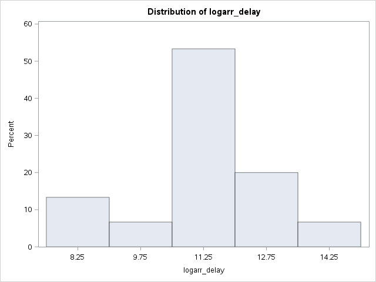

The UNIVARIATE Procedure

IATA_CODE=ATL

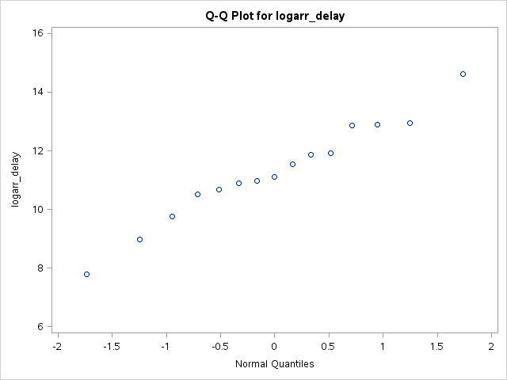

The UNIVARIATE Procedure

Variable: arr_delay (arr_delay)

IATA_CODE=BOS

| Moments |  |  |  |
| --- | --- | --- | --- |
| N | 14 | Sum Weights | 14 |
| Mean | 168224.857 | Sum Observations | 2355148 |
| Std Deviation | 260027.152 | Variance | 6.76141E10 |
| Skewness | 2.81953624 | Kurtosis | 8.79832318 |
| Uncorrected SS | 1.27518E12 | Corrected SS | 8.78984E11 |
| Coeff Variation | 154.571183 | Std Error Mean | 69495.1796 |

| Basic Statistical Measures Location | Basic Statistical Measures Location | Basic Statistical Measures Variability | Basic Statistical Measures Variability |
| --- | --- | --- | --- |
| Mean | 168224.9 | Std Deviation | 260027 |
| Median | 80247.5 | Variance | 6.76141E10 |
| Mode | . | Range | 994471 |
|  |  | Interquartile Range | 198862 |

| Tests for Location: Mu0=0 Test | Tests for Location: Mu0=0 Statistic | Tests for Location: Mu0=0 Statistic | Tests for Location: Mu0=0 p Value | Tests for Location: Mu0=0 p Value |
| --- | --- | --- | --- | --- |
| Student's t | t | 2.420669 | Pr > \|t\| | 0.0309 |
| Sign | M | 7 | Pr >= \|M\| | 0.0001 |
| Signed Rank | S | 52.5 | Pr >= \|S\| | 0.0001 |

| Quantiles (Definition 5) Level | Quantiles (Definition 5) Quantile |
| --- | --- |
| 100% Max | 995159.0 |
| 99% | 995159.0 |
| 95% | 995159.0 |
| 90% | 364099.0 |
| 75% Q3 | 225308.0 |
| 50% Median | 80247.5 |
| 25% Q1 | 26446.0 |
| 10% | 1638.0 |
| 5% | 688.0 |
| 1% | 688.0 |
| 0% Min | 688.0 |

| Extreme Observations Lowest Value | Extreme Observations Lowest Obs | Extreme Observations Highest Value | Extreme Observations Highest Obs |
| --- | --- | --- | --- |
| 688 | 28 | 155107 | 27 |
| 1638 | 26 | 225308 | 25 |
| 23043 | 21 | 227065 | 20 |
| 26446 | 22 | 364099 | 17 |
| 33076 | 18 | 995159 | 19 |

The UNIVARIATE Procedure

Variable: logarr_delay

IATA_CODE=BOS

| Moments |  |  |  |
| --- | --- | --- | --- |
| N | 14 | Sum Weights | 14 |
| Mean | 10.9065312 | Sum Observations | 152.691437 |
| Std Deviation | 1.97319121 | Variance | 3.89348356 |
| Skewness | -1.0439889 | Kurtosis | 1.09216151 |
| Uncorrected SS | 1715.94922 | Corrected SS | 50.6152863 |
| Coeff Variation | 18.0918311 | Std Error Mean | 0.52735753 |

| Basic Statistical Measures Location | Basic Statistical Measures Location | Basic Statistical Measures Variability | Basic Statistical Measures Variability |
| --- | --- | --- | --- |
| Mean | 10.90653 | Std Deviation | 1.97319 |
| Median | 11.29240 | Variance | 3.89348 |
| Mode | . | Range | 7.27687 |
|  |  | Interquartile Range | 2.14236 |

| Tests for Location: Mu0=0 Test | Tests for Location: Mu0=0 Statistic | Tests for Location: Mu0=0 Statistic | Tests for Location: Mu0=0 p Value | Tests for Location: Mu0=0 p Value |
| --- | --- | --- | --- | --- |
| Student's t | t | 20.68147 | Pr > \|t\| | <.0001 |
| Sign | M | 7 | Pr >= \|M\| | 0.0001 |
| Signed Rank | S | 52.5 | Pr >= \|S\| | 0.0001 |

| Quantiles (Definition 5) Level | Quantiles (Definition 5) Quantile |
| --- | --- |
| 100% Max | 13.81066 |
| 99% | 13.81066 |
| 95% | 13.81066 |
| 90% | 12.80518 |
| 75% Q3 | 12.32522 |
| 50% Median | 11.29240 |
| 25% Q1 | 10.18286 |
| 10% | 7.40123 |
| 5% | 6.53379 |
| 1% | 6.53379 |
| 0% Min | 6.53379 |

| Extreme Observations Lowest Value | Extreme Observations Lowest Obs | Extreme Observations Highest Value | Extreme Observations Highest Obs |
| --- | --- | --- | --- |
| 6.53379 | 28 | 11.9519 | 27 |
| 7.40123 | 26 | 12.3252 | 25 |
| 10.04512 | 21 | 12.3330 | 20 |
| 10.18286 | 22 | 12.8052 | 17 |
| 10.40656 | 18 | 13.8107 | 19 |

The UNIVARIATE Procedure

IATA_CODE=BOS

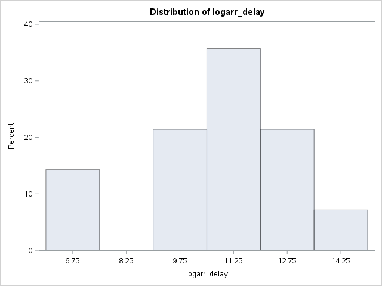

The UNIVARIATE Procedure

IATA_CODE=BOS

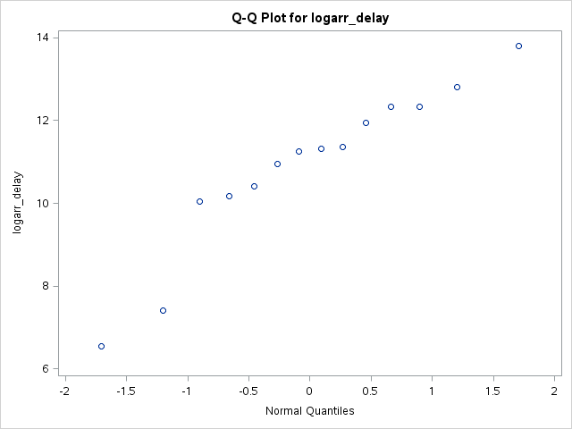

The UNIVARIATE Procedure

Variable: arr_delay (arr_delay)

IATA_CODE=BWI

| Moments |  |  |  |
| --- | --- | --- | --- |
| N | 15 | Sum Weights | 15 |
| Mean | 69509.6 | Sum Observations | 1042644 |
| Std Deviation | 155494.457 | Variance | 2.41785E10 |
| Skewness | 3.59751221 | Kurtosis | 13.4292923 |
| Uncorrected SS | 4.10973E11 | Corrected SS | 3.38499E11 |
| Coeff Variation | 223.702131 | Std Error Mean | 40148.496 |

| Basic Statistical Measures Location | Basic Statistical Measures Location | Basic Statistical Measures Variability | Basic Statistical Measures Variability |
| --- | --- | --- | --- |
| Mean | 69509.60 | Std Deviation | 155494 |
| Median | 17604.00 | Variance | 2.41785E10 |
| Mode | . | Range | 619124 |
|  |  | Interquartile Range | 57666 |

| Tests for Location: Mu0=0 Test | Tests for Location: Mu0=0 Statistic | Tests for Location: Mu0=0 Statistic | Tests for Location: Mu0=0 p Value | Tests for Location: Mu0=0 p Value |
| --- | --- | --- | --- | --- |
| Student's t | t | 1.731313 | Pr > \|t\| | 0.1054 |
| Sign | M | 7.5 | Pr >= \|M\| | <.0001 |
| Signed Rank | S | 60 | Pr >= \|S\| | <.0001 |

| Quantiles (Definition 5) Level | Quantiles (Definition 5) Quantile |
| --- | --- |
| 100% Max | 619284 |
| 99% | 619284 |
| 95% | 619284 |
| 90% | 110449 |
| 75% Q3 | 61981 |
| 50% Median | 17604 |
| 25% Q1 | 4315 |
| 10% | 2336 |
| 5% | 160 |
| 1% | 160 |
| 0% Min | 160 |

| Extreme Observations Lowest Value | Extreme Observations Lowest Obs | Extreme Observations Highest Value | Extreme Observations Highest Obs |
| --- | --- | --- | --- |
| 160 | 42 | 52995 | 33 |
| 2336 | 39 | 61981 | 34 |
| 2999 | 44 | 72332 | 31 |
| 4315 | 40 | 110449 | 38 |
| 4623 | 36 | 619284 | 43 |

The UNIVARIATE Procedure

Variable: logarr_delay

IATA_CODE=BWI

| Moments |  |  |  |
| --- | --- | --- | --- |
| N | 15 | Sum Weights | 15 |
| Mean | 9.65194558 | Sum Observations | 144.779184 |
| Std Deviation | 1.99477577 | Variance | 3.97913038 |
| Skewness | -0.4597643 | Kurtosis | 0.92141349 |
| Uncorrected SS | 1453.10863 | Corrected SS | 55.7078253 |
| Coeff Variation | 20.6670847 | Std Error Mean | 0.51504889 |

| Basic Statistical Measures Location | Basic Statistical Measures Location | Basic Statistical Measures Variability | Basic Statistical Measures Variability |
| --- | --- | --- | --- |
| Mean | 9.651946 | Std Deviation | 1.99478 |
| Median | 9.775881 | Variance | 3.97913 |
| Mode | . | Range | 8.26115 |
|  |  | Interquartile Range | 2.66473 |

| Tests for Location: Mu0=0 Test | Tests for Location: Mu0=0 Statistic | Tests for Location: Mu0=0 Statistic | Tests for Location: Mu0=0 p Value | Tests for Location: Mu0=0 p Value |
| --- | --- | --- | --- | --- |
| Student's t | t | 18.73986 | Pr > \|t\| | <.0001 |
| Sign | M | 7.5 | Pr >= \|M\| | <.0001 |
| Signed Rank | S | 60 | Pr >= \|S\| | <.0001 |

| Quantiles (Definition 5) Level | Quantiles (Definition 5) Quantile |
| --- | --- |
| 100% Max | 13.33632 |
| 99% | 13.33632 |
| 95% | 13.33632 |
| 90% | 11.61231 |
| 75% Q3 | 11.03458 |
| 50% Median | 9.77588 |
| 25% Q1 | 8.36985 |
| 10% | 7.75620 |
| 5% | 5.07517 |
| 1% | 5.07517 |
| 0% Min | 5.07517 |

| Extreme Observations Lowest Value | Extreme Observations Lowest Obs | Extreme Observations Highest Value | Extreme Observations Highest Obs |
| --- | --- | --- | --- |
| 5.07517 | 42 | 10.8780 | 33 |
| 7.75620 | 39 | 11.0346 | 34 |
| 8.00603 | 44 | 11.1890 | 31 |
| 8.36985 | 40 | 11.6123 | 38 |
| 8.43880 | 36 | 13.3363 | 43 |

The UNIVARIATE Procedure

IATA_CODE=BWI

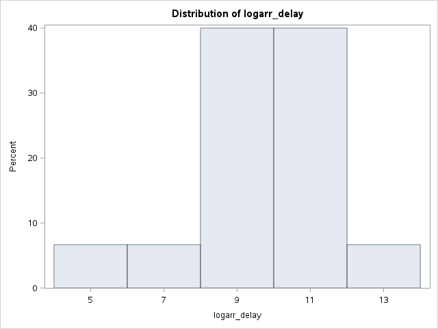

The UNIVARIATE Procedure

IATA_CODE=BWI

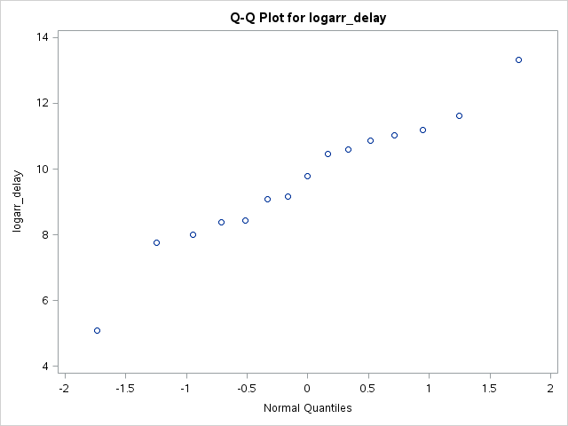

The UNIVARIATE Procedure

Variable: arr_delay (arr_delay)

IATA_CODE=CLT

| Moments |  |  |  |
| --- | --- | --- | --- |
| N | 13 | Sum Weights | 13 |
| Mean | 183624.923 | Sum Observations | 2387124 |
| Std Deviation | 354652.129 | Variance | 1.25778E11 |
| Skewness | 2.25704362 | Kurtosis | 3.86706759 |
| Uncorrected SS | 1.94767E12 | Corrected SS | 1.50934E12 |
| Coeff Variation | 193.13943 | Std Error Mean | 98362.8028 |

| Basic Statistical Measures Location | Basic Statistical Measures Location | Basic Statistical Measures Variability | Basic Statistical Measures Variability |
| --- | --- | --- | --- |
| Mean | 183624.9 | Std Deviation | 354652 |
| Median | 41132.0 | Variance | 1.25778E11 |
| Mode | . | Range | 1074547 |
|  |  | Interquartile Range | 20819 |

| Tests for Location: Mu0=0 Test | Tests for Location: Mu0=0 Statistic | Tests for Location: Mu0=0 Statistic | Tests for Location: Mu0=0 p Value | Tests for Location: Mu0=0 p Value |
| --- | --- | --- | --- | --- |
| Student's t | t | 1.866813 | Pr > \|t\| | 0.0865 |
| Sign | M | 6.5 | Pr >= \|M\| | 0.0002 |
| Signed Rank | S | 45.5 | Pr >= \|S\| | 0.0002 |

| Quantiles (Definition 5) Level | Quantiles (Definition 5) Quantile |
| --- | --- |
| 100% Max | 1093929 |
| 99% | 1093929 |
| 95% | 1093929 |
| 90% | 854523 |
| 75% Q3 | 50100 |
| 50% Median | 41132 |
| 25% Q1 | 29281 |
| 10% | 24253 |
| 5% | 19382 |
| 1% | 19382 |
| 0% Min | 19382 |

| Extreme Observations Lowest Value | Extreme Observations Lowest Obs | Extreme Observations Highest Value | Extreme Observations Highest Obs |
| --- | --- | --- | --- |
| 19382 | 54 | 43070 | 51 |
| 24253 | 47 | 50100 | 49 |
| 27666 | 50 | 86885 | 57 |
| 29281 | 56 | 854523 | 46 |
| 34410 | 45 | 1093929 | 52 |

The UNIVARIATE Procedure

Variable: logarr_delay

IATA_CODE=CLT

| Moments |  |  |  |
| --- | --- | --- | --- |
| N | 13 | Sum Weights | 13 |
| Mean | 11.0179639 | Sum Observations | 143.23353 |
| Std Deviation | 1.28150484 | Variance | 1.64225466 |
| Skewness | 1.8216444 | Kurtosis | 2.28085785 |
| Uncorrected SS | 1597.84892 | Corrected SS | 19.7070559 |
| Coeff Variation | 11.6310496 | Std Error Mean | 0.35542549 |

| Basic Statistical Measures Location | Basic Statistical Measures Location | Basic Statistical Measures Variability | Basic Statistical Measures Variability |
| --- | --- | --- | --- |
| Mean | 11.01796 | Std Deviation | 1.28150 |
| Median | 10.62454 | Variance | 1.64225 |
| Mode | . | Range | 4.03319 |
|  |  | Interquartile Range | 0.53708 |

| Tests for Location: Mu0=0 Test | Tests for Location: Mu0=0 Statistic | Tests for Location: Mu0=0 Statistic | Tests for Location: Mu0=0 p Value | Tests for Location: Mu0=0 p Value |
| --- | --- | --- | --- | --- |
| Student's t | t | 30.99936 | Pr > \|t\| | <.0001 |
| Sign | M | 6.5 | Pr >= \|M\| | 0.0002 |
| Signed Rank | S | 45.5 | Pr >= \|S\| | 0.0002 |

| Quantiles (Definition 5) Level | Quantiles (Definition 5) Quantile |
| --- | --- |
| 100% Max | 13.9053 |
| 99% | 13.9053 |
| 95% | 13.9053 |
| 90% | 13.6583 |
| 75% Q3 | 10.8218 |
| 50% Median | 10.6245 |
| 25% Q1 | 10.2847 |
| 10% | 10.0963 |
| 5% | 9.8721 |
| 1% | 9.8721 |
| 0% Min | 9.8721 |

| Extreme Observations Lowest Value | Extreme Observations Lowest Obs | Extreme Observations Highest Value | Extreme Observations Highest Obs |
| --- | --- | --- | --- |
| 9.8721 | 54 | 10.6706 | 51 |
| 10.0963 | 47 | 10.8218 | 49 |
| 10.2280 | 50 | 11.3723 | 57 |
| 10.2847 | 56 | 13.6583 | 46 |
| 10.4461 | 45 | 13.9053 | 52 |

The UNIVARIATE Procedure

IATA_CODE=CLT

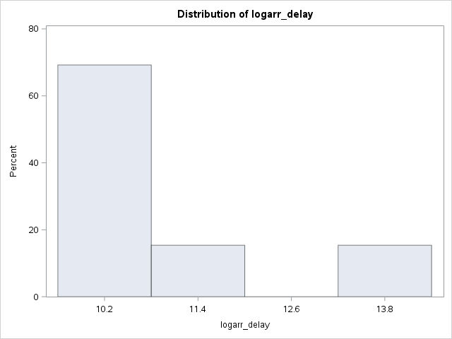

The UNIVARIATE Procedure

IATA_CODE=CLT

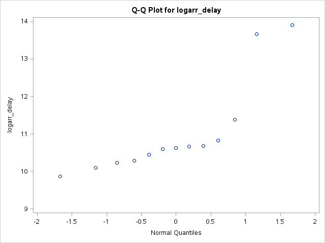

The UNIVARIATE Procedure

Variable: arr_delay (arr_delay)

IATA_CODE=DEN

| Moments |  |  |  |
| --- | --- | --- | --- |
| N | 13 | Sum Weights | 13 |
| Mean | 199087.692 | Sum Observations | 2588140 |
| Std Deviation | 259239.941 | Variance | 6.72053E10 |
| Skewness | 0.98531357 | Kurtosis | -0.9701223 |
| Uncorrected SS | 1.32173E12 | Corrected SS | 8.06464E11 |
| Coeff Variation | 130.213946 | Std Error Mean | 71900.223 |

| Basic Statistical Measures Location | Basic Statistical Measures Location | Basic Statistical Measures Variability | Basic Statistical Measures Variability |
| --- | --- | --- | --- |
| Mean | 199087.7 | Std Deviation | 259240 |
| Median | 43115.0 | Variance | 6.72053E10 |
| Mode | . | Range | 630160 |
|  |  | Interquartile Range | 413103 |

| Tests for Location: Mu0=0 Test | Tests for Location: Mu0=0 Statistic | Tests for Location: Mu0=0 Statistic | Tests for Location: Mu0=0 p Value | Tests for Location: Mu0=0 p Value |
| --- | --- | --- | --- | --- |
| Student's t | t | 2.768944 | Pr > \|t\| | 0.0170 |
| Sign | M | 6.5 | Pr >= \|M\| | 0.0002 |
| Signed Rank | S | 45.5 | Pr >= \|S\| | 0.0002 |

| Quantiles (Definition 5) Level | Quantiles (Definition 5) Quantile |
| --- | --- |
| 100% Max | 630472 |
| 99% | 630472 |
| 95% | 630472 |
| 90% | 624019 |
| 75% Q3 | 426767 |
| 50% Median | 43115 |
| 25% Q1 | 13664 |
| 10% | 1747 |
| 5% | 312 |
| 1% | 312 |
| 0% Min | 312 |

| Extreme Observations Lowest Value | Extreme Observations Lowest Obs | Extreme Observations Highest Value | Extreme Observations Highest Obs |
| --- | --- | --- | --- |
| 312 | 58 | 133873 | 59 |
| 1747 | 68 | 426767 | 63 |
| 2604 | 64 | 568842 | 67 |
| 13664 | 60 | 624019 | 69 |
| 17026 | 61 | 630472 | 66 |

The UNIVARIATE Procedure

Variable: logarr_delay

IATA_CODE=DEN

| Moments |  |  |  |
| --- | --- | --- | --- |
| N | 13 | Sum Weights | 13 |
| Mean | 10.5920046 | Sum Observations | 137.69606 |
| Std Deviation | 2.45864882 | Variance | 6.04495401 |
| Skewness | -0.5990795 | Kurtosis | -0.5115414 |
| Uncorrected SS | 1531.01675 | Corrected SS | 72.5394481 |
| Coeff Variation | 23.2123088 | Std Error Mean | 0.68190649 |

| Basic Statistical Measures Location | Basic Statistical Measures Location | Basic Statistical Measures Variability | Basic Statistical Measures Variability |
| --- | --- | --- | --- |
| Mean | 10.59200 | Std Deviation | 2.45865 |
| Median | 10.67163 | Variance | 6.04495 |
| Mode | . | Range | 7.61122 |
|  |  | Interquartile Range | 3.44147 |

| Tests for Location: Mu0=0 Test | Tests for Location: Mu0=0 Statistic | Tests for Location: Mu0=0 Statistic | Tests for Location: Mu0=0 p Value | Tests for Location: Mu0=0 p Value |
| --- | --- | --- | --- | --- |
| Student's t | t | 15.53293 | Pr > \|t\| | <.0001 |
| Sign | M | 6.5 | Pr >= \|M\| | 0.0002 |
| Signed Rank | S | 45.5 | Pr >= \|S\| | 0.0002 |

| Quantiles (Definition 5) Level | Quantiles (Definition 5) Quantile |
| --- | --- |
| 100% Max | 13.35422 |
| 99% | 13.35422 |
| 95% | 13.35422 |
| 90% | 13.34394 |
| 75% Q3 | 12.96399 |
| 50% Median | 10.67163 |
| 25% Q1 | 9.52252 |
| 10% | 7.46566 |
| 5% | 5.74300 |
| 1% | 5.74300 |
| 0% Min | 5.74300 |

| Extreme Observations Lowest Value | Extreme Observations Lowest Obs | Extreme Observations Highest Value | Extreme Observations Highest Obs |
| --- | --- | --- | --- |
| 5.74300 | 58 | 11.8046 | 59 |
| 7.46566 | 68 | 12.9640 | 63 |
| 7.86480 | 64 | 13.2514 | 67 |
| 9.52252 | 60 | 13.3439 | 69 |
| 9.74250 | 61 | 13.3542 | 66 |

The UNIVARIATE Procedure

IATA_CODE=DEN

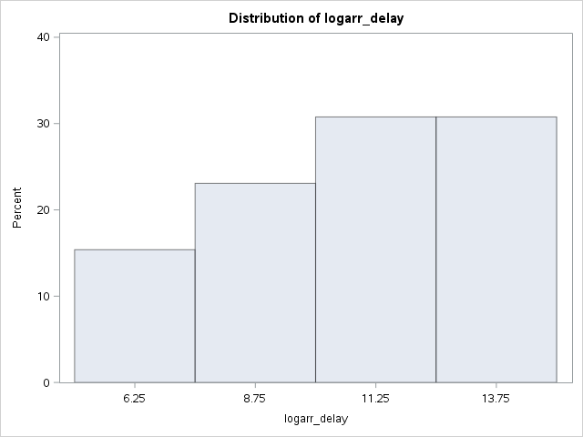

The UNIVARIATE Procedure

IATA_CODE=DEN

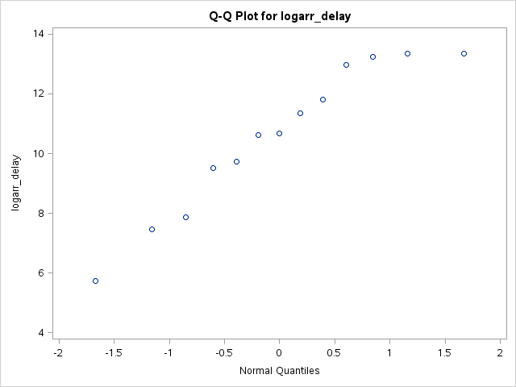

The UNIVARIATE Procedure

Variable: arr_delay (arr_delay)

IATA_CODE=DFW

| Moments |  |  |  |
| --- | --- | --- | --- |
| N | 13 | Sum Weights | 13 |
| Mean | 295006.308 | Sum Observations | 3835082 |
| Std Deviation | 523727.131 | Variance | 2.7429E11 |
| Skewness | 2.84834872 | Kurtosis | 8.73907782 |
| Uncorrected SS | 4.42285E12 | Corrected SS | 3.29148E12 |
| Coeff Variation | 177.530825 | Std Error Mean | 145255.771 |

| Basic Statistical Measures Location | Basic Statistical Measures Location | Basic Statistical Measures Variability | Basic Statistical Measures Variability |
| --- | --- | --- | --- |
| Mean | 295006.3 | Std Deviation | 523727 |
| Median | 103687.0 | Variance | 2.7429E11 |
| Mode | . | Range | 1906428 |
|  |  | Interquartile Range | 179892 |

| Tests for Location: Mu0=0 Test | Tests for Location: Mu0=0 Statistic | Tests for Location: Mu0=0 Statistic | Tests for Location: Mu0=0 p Value | Tests for Location: Mu0=0 p Value |
| --- | --- | --- | --- | --- |
| Student's t | t | 2.030944 | Pr > \|t\| | 0.0650 |
| Sign | M | 6.5 | Pr >= \|M\| | 0.0002 |
| Signed Rank | S | 45.5 | Pr >= \|S\| | 0.0002 |

| Quantiles (Definition 5) Level | Quantiles (Definition 5) Quantile |
| --- | --- |
| 100% Max | 1913732 |
| 99% | 1913732 |
| 95% | 1913732 |
| 90% | 580050 |
| 75% Q3 | 206132 |
| 50% Median | 103687 |
| 25% Q1 | 26240 |
| 10% | 8889 |
| 5% | 7304 |
| 1% | 7304 |
| 0% Min | 7304 |

| Extreme Observations Lowest Value | Extreme Observations Lowest Obs | Extreme Observations Highest Value | Extreme Observations Highest Obs |
| --- | --- | --- | --- |
| 7304 | 73 | 147415 | 79 |
| 8889 | 74 | 206132 | 76 |
| 12623 | 77 | 565594 | 78 |
| 26240 | 71 | 580050 | 82 |
| 51437 | 83 | 1913732 | 72 |

The UNIVARIATE Procedure

Variable: logarr_delay

IATA_CODE=DFW

| Moments |  |  |  |
| --- | --- | --- | --- |
| N | 13 | Sum Weights | 13 |
| Mean | 11.3937107 | Sum Observations | 148.118239 |
| Std Deviation | 1.70335373 | Variance | 2.90141394 |
| Skewness | 0.11153533 | Kurtosis | -0.6931981 |
| Uncorrected SS | 1722.43334 | Corrected SS | 34.8169673 |
| Coeff Variation | 14.9499472 | Std Error Mean | 0.47242533 |

| Basic Statistical Measures Location | Basic Statistical Measures Location | Basic Statistical Measures Variability | Basic Statistical Measures Variability |
| --- | --- | --- | --- |
| Mean | 11.39371 | Std Deviation | 1.70335 |
| Median | 11.54913 | Variance | 2.90141 |
| Mode | . | Range | 5.56839 |
|  |  | Interquartile Range | 2.06123 |

| Tests for Location: Mu0=0 Test | Tests for Location: Mu0=0 Statistic | Tests for Location: Mu0=0 Statistic | Tests for Location: Mu0=0 p Value | Tests for Location: Mu0=0 p Value |
| --- | --- | --- | --- | --- |
| Student's t | t | 24.11749 | Pr > \|t\| | <.0001 |
| Sign | M | 6.5 | Pr >= \|M\| | 0.0002 |
| Signed Rank | S | 45.5 | Pr >= \|S\| | 0.0002 |

| Quantiles (Definition 5) Level | Quantiles (Definition 5) Quantile |
| --- | --- |
| 100% Max | 14.46457 |
| 99% | 14.46457 |
| 95% | 14.46457 |
| 90% | 13.27087 |
| 75% Q3 | 12.23627 |
| 50% Median | 11.54913 |
| 25% Q1 | 10.17504 |
| 10% | 9.09257 |
| 5% | 8.89618 |
| 1% | 8.89618 |
| 0% Min | 8.89618 |

| Extreme Observations Lowest Value | Extreme Observations Lowest Obs | Extreme Observations Highest Value | Extreme Observations Highest Obs |
| --- | --- | --- | --- |
| 8.89618 | 73 | 11.9010 | 79 |
| 9.09257 | 74 | 12.2363 | 76 |
| 9.44328 | 77 | 13.2456 | 78 |
| 10.17504 | 71 | 13.2709 | 82 |
| 10.84811 | 83 | 14.4646 | 72 |

The UNIVARIATE Procedure

IATA_CODE=DFW

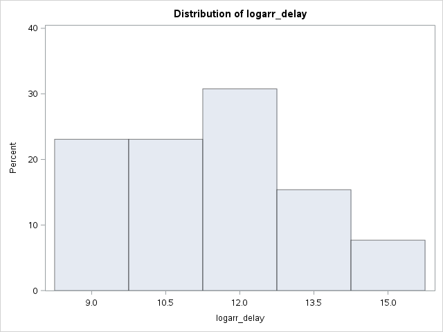

The UNIVARIATE Procedure

IATA_CODE=DFW

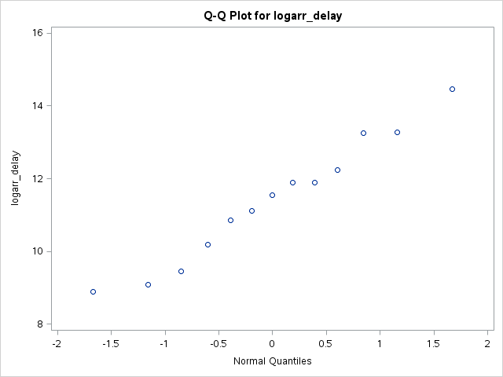

The UNIVARIATE Procedure

Variable: arr_delay (arr_delay)

IATA_CODE=DTW

| Moments |  |  |  |
| --- | --- | --- | --- |
| N | 15 | Sum Weights | 15 |
| Mean | 115347.267 | Sum Observations | 1730209 |
| Std Deviation | 172391.944 | Variance | 2.9719E10 |
| Skewness | 2.18506412 | Kurtosis | 4.24747159 |
| Uncorrected SS | 6.15641E11 | Corrected SS | 4.16066E11 |
| Coeff Variation | 149.454728 | Std Error Mean | 44511.4086 |

| Basic Statistical Measures Location | Basic Statistical Measures Location | Basic Statistical Measures Variability | Basic Statistical Measures Variability |
| --- | --- | --- | --- |
| Mean | 115347.3 | Std Deviation | 172392 |
| Median | 35482.0 | Variance | 2.9719E10 |
| Mode | . | Range | 594545 |
|  |  | Interquartile Range | 115889 |

| Tests for Location: Mu0=0 Test | Tests for Location: Mu0=0 Statistic | Tests for Location: Mu0=0 Statistic | Tests for Location: Mu0=0 p Value | Tests for Location: Mu0=0 p Value |
| --- | --- | --- | --- | --- |
| Student's t | t | 2.591409 | Pr > \|t\| | 0.0213 |
| Sign | M | 7.5 | Pr >= \|M\| | <.0001 |
| Signed Rank | S | 60 | Pr >= \|S\| | <.0001 |

| Quantiles (Definition 5) Level | Quantiles (Definition 5) Quantile |
| --- | --- |
| 100% Max | 597712 |
| 99% | 597712 |
| 95% | 597712 |
| 90% | 427901 |
| 75% Q3 | 135274 |
| 50% Median | 35482 |
| 25% Q1 | 19385 |
| 10% | 12355 |
| 5% | 3167 |
| 1% | 3167 |
| 0% Min | 3167 |

| Extreme Observations Lowest Value | Extreme Observations Lowest Obs | Extreme Observations Highest Value | Extreme Observations Highest Obs |
| --- | --- | --- | --- |
| 3167 | 86 | 83683 | 98 |
| 12355 | 91 | 135274 | 92 |
| 14125 | 93 | 193000 | 84 |
| 19385 | 90 | 427901 | 88 |
| 19590 | 95 | 597712 | 94 |

The UNIVARIATE Procedure

Variable: logarr_delay

IATA_CODE=DTW

| Moments |  |  |  |
| --- | --- | --- | --- |
| N | 15 | Sum Weights | 15 |
| Mean | 10.769023 | Sum Observations | 161.535344 |
| Std Deviation | 1.40701666 | Variance | 1.9796959 |
| Skewness | 0.15159598 | Kurtosis | -0.1148188 |
| Uncorrected SS | 1767.29358 | Corrected SS | 27.7157425 |
| Coeff Variation | 13.0654069 | Std Error Mean | 0.36329014 |

| Basic Statistical Measures Location | Basic Statistical Measures Location | Basic Statistical Measures Variability | Basic Statistical Measures Variability |
| --- | --- | --- | --- |
| Mean | 10.76902 | Std Deviation | 1.40702 |
| Median | 10.47678 | Variance | 1.97970 |
| Mode | . | Range | 5.24032 |
|  |  | Interquartile Range | 1.94280 |

| Tests for Location: Mu0=0 Test | Tests for Location: Mu0=0 Statistic | Tests for Location: Mu0=0 Statistic | Tests for Location: Mu0=0 p Value | Tests for Location: Mu0=0 p Value |
| --- | --- | --- | --- | --- |
| Student's t | t | 29.64304 | Pr > \|t\| | <.0001 |
| Sign | M | 7.5 | Pr >= \|M\| | <.0001 |
| Signed Rank | S | 60 | Pr >= \|S\| | <.0001 |

| Quantiles (Definition 5) Level | Quantiles (Definition 5) Quantile |
| --- | --- |
| 100% Max | 13.30086 |
| 99% | 13.30086 |
| 95% | 13.30086 |
| 90% | 12.96665 |
| 75% Q3 | 11.81506 |
| 50% Median | 10.47678 |
| 25% Q1 | 9.87225 |
| 10% | 9.42182 |
| 5% | 8.06054 |
| 1% | 8.06054 |
| 0% Min | 8.06054 |

| Extreme Observations Lowest Value | Extreme Observations Lowest Obs | Extreme Observations Highest Value | Extreme Observations Highest Obs |
| --- | --- | --- | --- |
| 8.06054 | 86 | 11.3348 | 98 |
| 9.42182 | 91 | 11.8151 | 92 |
| 9.55570 | 93 | 12.1704 | 84 |
| 9.87225 | 90 | 12.9666 | 88 |
| 9.88277 | 95 | 13.3009 | 94 |

The UNIVARIATE Procedure

IATA_CODE=DTW

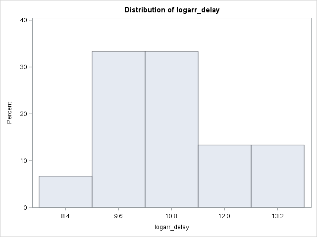

The UNIVARIATE Procedure

IATA_CODE=DTW

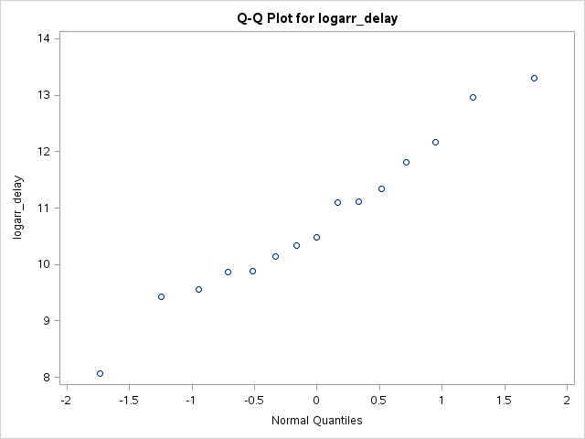

The UNIVARIATE Procedure

Variable: arr_delay (arr_delay)

IATA_CODE=EWR

| Moments |  |  |  |
| --- | --- | --- | --- |
| N | 15 | Sum Weights | 15 |
| Mean | 218115.267 | Sum Observations | 3271729 |
| Std Deviation | 335543.449 | Variance | 1.12589E11 |
| Skewness | 2.42335721 | Kurtosis | 6.32671809 |
| Uncorrected SS | 2.28987E12 | Corrected SS | 1.57625E12 |
| Coeff Variation | 153.837672 | Std Error Mean | 86636.946 |

| Basic Statistical Measures Location | Basic Statistical Measures Location | Basic Statistical Measures Variability | Basic Statistical Measures Variability |
| --- | --- | --- | --- |
| Mean | 218115.3 | Std Deviation | 335543 |
| Median | 80666.0 | Variance | 1.12589E11 |
| Mode | . | Range | 1247592 |
|  |  | Interquartile Range | 269974 |

| Tests for Location: Mu0=0 Test | Tests for Location: Mu0=0 Statistic | Tests for Location: Mu0=0 Statistic | Tests for Location: Mu0=0 p Value | Tests for Location: Mu0=0 p Value |
| --- | --- | --- | --- | --- |
| Student's t | t | 2.517578 | Pr > \|t\| | 0.0246 |
| Sign | M | 7.5 | Pr >= \|M\| | <.0001 |
| Signed Rank | S | 60 | Pr >= \|S\| | <.0001 |

| Quantiles (Definition 5) Level | Quantiles (Definition 5) Quantile |
| --- | --- |
| 100% Max | 1248465 |
| 99% | 1248465 |
| 95% | 1248465 |
| 90% | 608571 |
| 75% Q3 | 277064 |
| 50% Median | 80666 |
| 25% Q1 | 7090 |
| 10% | 5009 |
| 5% | 873 |
| 1% | 873 |
| 0% Min | 873 |

| Extreme Observations Lowest Value | Extreme Observations Lowest Obs | Extreme Observations Highest Value | Extreme Observations Highest Obs |
| --- | --- | --- | --- |
| 873 | 108 | 152651 | 100 |
| 5009 | 105 | 277064 | 102 |
| 6769 | 106 | 457720 | 113 |
| 7090 | 111 | 608571 | 104 |
| 39579 | 109 | 1248465 | 110 |

The UNIVARIATE Procedure

Variable: logarr_delay

IATA_CODE=EWR

| Moments |  |  |  |
| --- | --- | --- | --- |
| N | 15 | Sum Weights | 15 |
| Mean | 11.0206221 | Sum Observations | 165.309331 |
| Std Deviation | 2.01576279 | Variance | 4.06329962 |
| Skewness | -0.605184 | Kurtosis | -0.1493068 |
| Uncorrected SS | 1878.69785 | Corrected SS | 56.8861947 |
| Coeff Variation | 18.2908258 | Std Error Mean | 0.52046771 |

| Basic Statistical Measures Location | Basic Statistical Measures Location | Basic Statistical Measures Variability | Basic Statistical Measures Variability |
| --- | --- | --- | --- |
| Mean | 11.02062 | Std Deviation | 2.01576 |
| Median | 11.29807 | Variance | 4.06330 |
| Mode | . | Range | 7.26549 |
|  |  | Interquartile Range | 3.66556 |

| Tests for Location: Mu0=0 Test | Tests for Location: Mu0=0 Statistic | Tests for Location: Mu0=0 Statistic | Tests for Location: Mu0=0 p Value | Tests for Location: Mu0=0 p Value |
| --- | --- | --- | --- | --- |
| Student's t | t | 21.17446 | Pr > \|t\| | <.0001 |
| Sign | M | 7.5 | Pr >= \|M\| | <.0001 |
| Signed Rank | S | 60 | Pr >= \|S\| | <.0001 |

| Quantiles (Definition 5) Level | Quantiles (Definition 5) Quantile |
| --- | --- |
| 100% Max | 14.03743 |
| 99% | 14.03743 |
| 95% | 14.03743 |
| 90% | 13.31887 |
| 75% Q3 | 12.53200 |
| 50% Median | 11.29807 |
| 25% Q1 | 8.86644 |
| 10% | 8.51899 |
| 5% | 6.77194 |
| 1% | 6.77194 |
| 0% Min | 6.77194 |

| Extreme Observations Lowest Value | Extreme Observations Lowest Obs | Extreme Observations Highest Value | Extreme Observations Highest Obs |
| --- | --- | --- | --- |
| 6.77194 | 108 | 11.9359 | 100 |
| 8.51899 | 105 | 12.5320 | 102 |
| 8.82011 | 106 | 13.0340 | 113 |
| 8.86644 | 111 | 13.3189 | 104 |
| 10.58605 | 109 | 14.0374 | 110 |

The UNIVARIATE Procedure

IATA_CODE=EWR

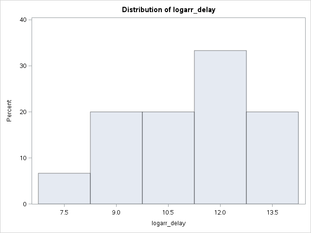

The UNIVARIATE Procedure

IATA_CODE=EWR

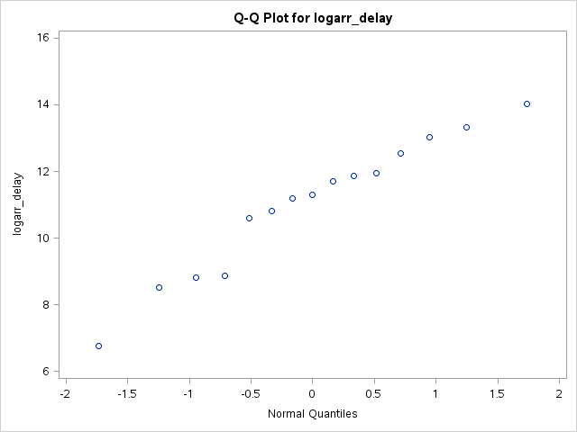

The UNIVARIATE Procedure

Variable: arr_delay (arr_delay)

IATA_CODE=FLL

| Moments |  |  |  |
| --- | --- | --- | --- |
| N | 12 | Sum Weights | 12 |
| Mean | 109052.333 | Sum Observations | 1308628 |
| Std Deviation | 143461.504 | Variance | 2.05812E10 |
| Skewness | 1.77301402 | Kurtosis | 3.25329199 |
| Uncorrected SS | 3.69102E11 | Corrected SS | 2.26393E11 |
| Coeff Variation | 131.552898 | Std Error Mean | 41413.7691 |

| Basic Statistical Measures Location | Basic Statistical Measures Location | Basic Statistical Measures Variability | Basic Statistical Measures Variability |
| --- | --- | --- | --- |
| Mean | 109052.3 | Std Deviation | 143462 |
| Median | 74490.5 | Variance | 2.05812E10 |
| Mode | . | Range | 475991 |
|  |  | Interquartile Range | 161816 |

| Tests for Location: Mu0=0 Test | Tests for Location: Mu0=0 Statistic | Tests for Location: Mu0=0 Statistic | Tests for Location: Mu0=0 p Value | Tests for Location: Mu0=0 p Value |
| --- | --- | --- | --- | --- |
| Student's t | t | 2.633239 | Pr > \|t\| | 0.0233 |
| Sign | M | 6 | Pr >= \|M\| | 0.0005 |
| Signed Rank | S | 39 | Pr >= \|S\| | 0.0005 |

| Quantiles (Definition 5) Level | Quantiles (Definition 5) Quantile |
| --- | --- |
| 100% Max | 477539.0 |
| 99% | 477539.0 |
| 95% | 477539.0 |
| 90% | 243610.0 |
| 75% Q3 | 163807.5 |
| 50% Median | 74490.5 |
| 25% Q1 | 1992.0 |
| 10% | 1634.0 |
| 5% | 1548.0 |
| 1% | 1548.0 |
| 0% Min | 1548.0 |

| Extreme Observations Lowest Value | Extreme Observations Lowest Obs | Extreme Observations Highest Value | Extreme Observations Highest Obs |
| --- | --- | --- | --- |
| 1548 | 122 | 96108 | 123 |
| 1634 | 114 | 102015 | 118 |
| 1784 | 119 | 225600 | 125 |
| 2200 | 124 | 243610 | 121 |
| 7609 | 116 | 477539 | 117 |

The UNIVARIATE Procedure

Variable: logarr_delay

IATA_CODE=FLL

| Moments |  |  |  |
| --- | --- | --- | --- |
| N | 12 | Sum Weights | 12 |
| Mean | 10.1760139 | Sum Observations | 122.112166 |
| Std Deviation | 2.22263824 | Variance | 4.94012074 |
| Skewness | -0.2819522 | Kurtosis | -1.8277917 |
| Uncorrected SS | 1296.95642 | Corrected SS | 54.3413282 |
| Coeff Variation | 21.8419341 | Std Error Mean | 0.64162039 |

| Basic Statistical Measures Location | Basic Statistical Measures Location | Basic Statistical Measures Variability | Basic Statistical Measures Variability |
| --- | --- | --- | --- |
| Mean | 10.17601 | Std Deviation | 2.22264 |
| Median | 11.21820 | Variance | 4.94012 |
| Mode | . | Range | 5.73168 |
|  |  | Interquartile Range | 4.33828 |

| Tests for Location: Mu0=0 Test | Tests for Location: Mu0=0 Statistic | Tests for Location: Mu0=0 Statistic | Tests for Location: Mu0=0 p Value | Tests for Location: Mu0=0 p Value |
| --- | --- | --- | --- | --- |
| Student's t | t | 15.85987 | Pr > \|t\| | <.0001 |
| Sign | M | 6 | Pr >= \|M\| | 0.0005 |
| Signed Rank | S | 39 | Pr >= \|S\| | 0.0005 |

| Quantiles (Definition 5) Level | Quantiles (Definition 5) Quantile |
| --- | --- |
| 100% Max | 13.07640 |
| 99% | 13.07640 |
| 95% | 13.07640 |
| 90% | 12.40332 |
| 75% Q3 | 11.92970 |
| 50% Median | 11.21820 |
| 25% Q1 | 7.59141 |
| 10% | 7.39879 |
| 5% | 7.34472 |
| 1% | 7.34472 |
| 0% Min | 7.34472 |

| Extreme Observations Lowest Value | Extreme Observations Lowest Obs | Extreme Observations Highest Value | Extreme Observations Highest Obs |
| --- | --- | --- | --- |
| 7.34472 | 122 | 11.4732 | 123 |
| 7.39879 | 114 | 11.5329 | 118 |
| 7.48661 | 119 | 12.3265 | 125 |
| 7.69621 | 124 | 12.4033 | 121 |
| 8.93709 | 116 | 13.0764 | 117 |

The UNIVARIATE Procedure

IATA_CODE=FLL

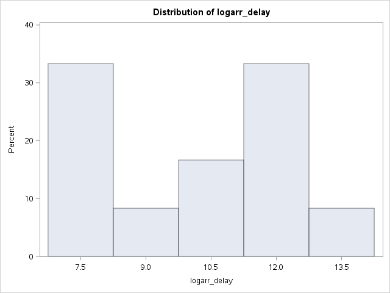

The UNIVARIATE Procedure

IATA_CODE=FLL

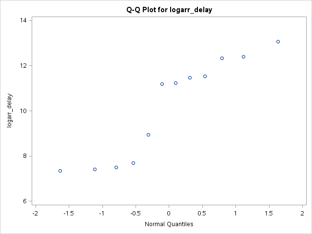

The UNIVARIATE Procedure

Variable: arr_delay (arr_delay)

IATA_CODE=IAD

| Moments |  |  |  |
| --- | --- | --- | --- |
| N | 14 | Sum Weights | 14 |
| Mean | 62029.5714 | Sum Observations | 868414 |
| Std Deviation | 103461.1 | Variance | 1.07042E10 |
| Skewness | 2.25684128 | Kurtosis | 3.78921735 |
| Uncorrected SS | 1.93022E11 | Corrected SS | 1.39155E11 |
| Coeff Variation | 166.793189 | Std Error Mean | 27651.1422 |

| Basic Statistical Measures Location | Basic Statistical Measures Location | Basic Statistical Measures Variability | Basic Statistical Measures Variability |
| --- | --- | --- | --- |
| Mean | 62029.57 | Std Deviation | 103461 |
| Median | 26163.00 | Variance | 1.07042E10 |
| Mode | . | Range | 320149 |
|  |  | Interquartile Range | 21937 |

| Tests for Location: Mu0=0 Test | Tests for Location: Mu0=0 Statistic | Tests for Location: Mu0=0 Statistic | Tests for Location: Mu0=0 p Value | Tests for Location: Mu0=0 p Value |
| --- | --- | --- | --- | --- |
| Student's t | t | 2.243291 | Pr > \|t\| | 0.0429 |
| Sign | M | 7 | Pr >= \|M\| | 0.0001 |
| Signed Rank | S | 52.5 | Pr >= \|S\| | 0.0001 |

| Quantiles (Definition 5) Level | Quantiles (Definition 5) Quantile |
| --- | --- |
| 100% Max | 321579 |
| 99% | 321579 |
| 95% | 321579 |
| 90% | 286871 |
| 75% Q3 | 36970 |
| 50% Median | 26163 |
| 25% Q1 | 15033 |
| 10% | 1538 |
| 5% | 1430 |
| 1% | 1430 |
| 0% Min | 1430 |

| Extreme Observations Lowest Value | Extreme Observations Lowest Obs | Extreme Observations Highest Value | Extreme Observations Highest Obs |
| --- | --- | --- | --- |
| 1430 | 136 | 31113 | 134 |
| 1538 | 139 | 36970 | 127 |
| 11291 | 131 | 38166 | 129 |
| 15033 | 128 | 286871 | 135 |
| 19258 | 126 | 321579 | 138 |

The UNIVARIATE Procedure

Variable: logarr_delay

IATA_CODE=IAD

| Moments |  |  |  |
| --- | --- | --- | --- |
| N | 14 | Sum Weights | 14 |
| Mean | 10.0547803 | Sum Observations | 140.766925 |
| Std Deviation | 1.51294301 | Variance | 2.28899654 |
| Skewness | -0.2069743 | Kurtosis | 0.89607605 |
| Uncorrected SS | 1445.13746 | Corrected SS | 29.756955 |
| Coeff Variation | 15.0470021 | Std Error Mean | 0.40435103 |

| Basic Statistical Measures Location | Basic Statistical Measures Location | Basic Statistical Measures Variability | Basic Statistical Measures Variability |
| --- | --- | --- | --- |
| Mean | 10.05478 | Std Deviation | 1.51294 |
| Median | 10.16846 | Variance | 2.28900 |
| Mode | . | Range | 5.41557 |
|  |  | Interquartile Range | 0.89986 |

| Tests for Location: Mu0=0 Test | Tests for Location: Mu0=0 Statistic | Tests for Location: Mu0=0 Statistic | Tests for Location: Mu0=0 p Value | Tests for Location: Mu0=0 p Value |
| --- | --- | --- | --- | --- |
| Student's t | t | 24.86646 | Pr > \|t\| | <.0001 |
| Sign | M | 7 | Pr >= \|M\| | 0.0001 |
| Signed Rank | S | 52.5 | Pr >= \|S\| | 0.0001 |

| Quantiles (Definition 5) Level | Quantiles (Definition 5) Quantile |
| --- | --- |
| 100% Max | 12.68100 |
| 99% | 12.68100 |
| 95% | 12.68100 |
| 90% | 12.56679 |
| 75% Q3 | 10.51786 |
| 50% Median | 10.16846 |
| 25% Q1 | 9.61800 |
| 10% | 7.33824 |
| 5% | 7.26543 |
| 1% | 7.26543 |
| 0% Min | 7.26543 |

| Extreme Observations Lowest Value | Extreme Observations Lowest Obs | Extreme Observations Highest Value | Extreme Observations Highest Obs |
| --- | --- | --- | --- |
| 7.26543 | 136 | 10.3454 | 134 |
| 7.33824 | 139 | 10.5179 | 127 |
| 9.33176 | 131 | 10.5497 | 129 |
| 9.61800 | 128 | 12.5668 | 135 |
| 9.86568 | 126 | 12.6810 | 138 |

The UNIVARIATE Procedure

IATA_CODE=IAD

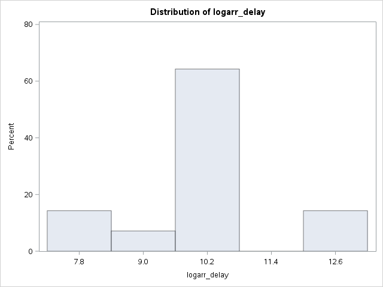

The UNIVARIATE Procedure

IATA_CODE=IAD

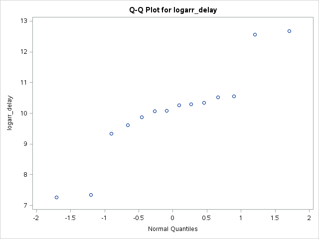

The UNIVARIATE Procedure

Variable: arr_delay (arr_delay)

IATA_CODE=IAH

| Moments |  |  |  |
| --- | --- | --- | --- |
| N | 12 | Sum Weights | 12 |
| Mean | 167427.333 | Sum Observations | 2009128 |
| Std Deviation | 210698.567 | Variance | 4.43939E10 |
| Skewness | 1.41766572 | Kurtosis | 0.94505532 |
| Uncorrected SS | 8.24716E11 | Corrected SS | 4.88333E11 |
| Coeff Variation | 125.844785 | Std Error Mean | 60823.4373 |

| Basic Statistical Measures Location | Basic Statistical Measures Location | Basic Statistical Measures Variability | Basic Statistical Measures Variability |
| --- | --- | --- | --- |
| Mean | 167427.3 | Std Deviation | 210699 |
| Median | 90142.0 | Variance | 4.43939E10 |
| Mode | . | Range | 637254 |
|  |  | Interquartile Range | 262833 |

| Tests for Location: Mu0=0 Test | Tests for Location: Mu0=0 Statistic | Tests for Location: Mu0=0 Statistic | Tests for Location: Mu0=0 p Value | Tests for Location: Mu0=0 p Value |
| --- | --- | --- | --- | --- |
| Student's t | t | 2.752678 | Pr > \|t\| | 0.0188 |
| Sign | M | 6 | Pr >= \|M\| | 0.0005 |
| Signed Rank | S | 39 | Pr >= \|S\| | 0.0005 |

| Quantiles (Definition 5) Level | Quantiles (Definition 5) Quantile |
| --- | --- |
| 100% Max | 641706.0 |
| 99% | 641706.0 |
| 95% | 641706.0 |
| 90% | 442845.0 |
| 75% Q3 | 278257.0 |
| 50% Median | 90142.0 |
| 25% Q1 | 15424.5 |
| 10% | 11290.0 |
| 5% | 4452.0 |
| 1% | 4452.0 |
| 0% Min | 4452.0 |

| Extreme Observations Lowest Value | Extreme Observations Lowest Obs | Extreme Observations Highest Value | Extreme Observations Highest Obs |
| --- | --- | --- | --- |
| 4452 | 142 | 113088 | 141 |
| 11290 | 146 | 153697 | 151 |
| 12869 | 145 | 402817 | 150 |
| 17980 | 140 | 442845 | 144 |
| 28100 | 143 | 641706 | 149 |

The UNIVARIATE Procedure

Variable: logarr_delay

IATA_CODE=IAH

| Moments |  |  |  |
| --- | --- | --- | --- |
| N | 12 | Sum Weights | 12 |
| Mean | 11.0735638 | Sum Observations | 132.882765 |
| Std Deviation | 1.61758307 | Variance | 2.616575 |
| Skewness | -0.1235103 | Kurtosis | -1.1841308 |
| Uncorrected SS | 1500.2681 | Corrected SS | 28.782325 |
| Coeff Variation | 14.6076106 | Std Error Mean | 0.46695601 |

| Basic Statistical Measures Location | Basic Statistical Measures Location | Basic Statistical Measures Variability | Basic Statistical Measures Variability |
| --- | --- | --- | --- |
| Mean | 11.07356 | Std Deviation | 1.61758 |
| Median | 11.39455 | Variance | 2.61658 |
| Mode | . | Range | 4.97078 |
|  |  | Interquartile Range | 2.79469 |

| Tests for Location: Mu0=0 Test | Tests for Location: Mu0=0 Statistic | Tests for Location: Mu0=0 Statistic | Tests for Location: Mu0=0 p Value | Tests for Location: Mu0=0 p Value |
| --- | --- | --- | --- | --- |
| Student's t | t | 23.71436 | Pr > \|t\| | <.0001 |
| Sign | M | 6 | Pr >= \|M\| | 0.0005 |
| Signed Rank | S | 39 | Pr >= \|S\| | 0.0005 |

| Quantiles (Definition 5) Level | Quantiles (Definition 5) Quantile |
| --- | --- |
| 100% Max | 13.37189 |
| 99% | 13.37189 |
| 95% | 13.37189 |
| 90% | 13.00098 |
| 75% Q3 | 12.42449 |
| 50% Median | 11.39455 |
| 25% Q1 | 9.62980 |
| 10% | 9.33167 |
| 5% | 8.40111 |
| 1% | 8.40111 |
| 0% Min | 8.40111 |

| Extreme Observations Lowest Value | Extreme Observations Lowest Obs | Extreme Observations Highest Value | Extreme Observations Highest Obs |
| --- | --- | --- | --- |
| 8.40111 | 142 | 11.6359 | 141 |
| 9.33167 | 146 | 11.9427 | 151 |
| 9.46258 | 145 | 12.9062 | 150 |
| 9.79702 | 140 | 13.0010 | 144 |
| 10.24352 | 143 | 13.3719 | 149 |

The UNIVARIATE Procedure

IATA_CODE=IAH

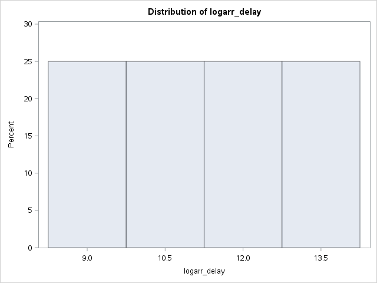

The UNIVARIATE Procedure

IATA_CODE=IAH

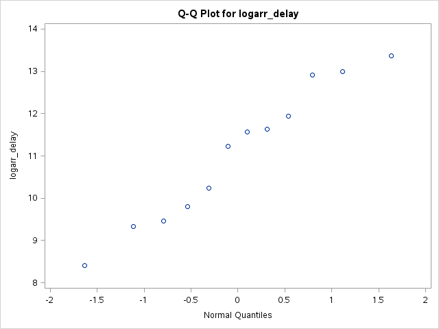

The UNIVARIATE Procedure

Variable: arr_delay (arr_delay)

IATA_CODE=JFK

| Moments |  |  |  |
| --- | --- | --- | --- |
| N | 11 | Sum Weights | 11 |
| Mean | 194040.273 | Sum Observations | 2134443 |
| Std Deviation | 263653.254 | Variance | 6.9513E10 |
| Skewness | 1.65749646 | Kurtosis | 2.49195044 |
| Uncorrected SS | 1.1093E12 | Corrected SS | 6.9513E11 |
| Coeff Variation | 135.875533 | Std Error Mean | 79494.4472 |

| Basic Statistical Measures Location | Basic Statistical Measures Location | Basic Statistical Measures Variability | Basic Statistical Measures Variability |
| --- | --- | --- | --- |
| Mean | 194040.3 | Std Deviation | 263653 |
| Median | 49636.0 | Variance | 6.9513E10 |
| Mode | . | Range | 826564 |
|  |  | Interquartile Range | 387674 |

| Tests for Location: Mu0=0 Test | Tests for Location: Mu0=0 Statistic | Tests for Location: Mu0=0 Statistic | Tests for Location: Mu0=0 p Value | Tests for Location: Mu0=0 p Value |
| --- | --- | --- | --- | --- |
| Student's t | t | 2.440929 | Pr > \|t\| | 0.0348 |
| Sign | M | 5.5 | Pr >= \|M\| | 0.0010 |
| Signed Rank | S | 33 | Pr >= \|S\| | 0.0010 |

| Quantiles (Definition 5) Level | Quantiles (Definition 5) Quantile |
| --- | --- |
| 100% Max | 831631 |
| 99% | 831631 |
| 95% | 831631 |
| 90% | 428358 |
| 75% Q3 | 396413 |
| 50% Median | 49636 |
| 25% Q1 | 8739 |
| 10% | 5713 |
| 5% | 5067 |
| 1% | 5067 |
| 0% Min | 5067 |

| Extreme Observations Lowest Value | Extreme Observations Lowest Obs | Extreme Observations Highest Value | Extreme Observations Highest Obs |
| --- | --- | --- | --- |
| 5067 | 157 | 75672 | 158 |
| 5713 | 159 | 256191 | 153 |
| 8739 | 161 | 396413 | 152 |
| 30463 | 162 | 428358 | 156 |
| 46560 | 160 | 831631 | 155 |

The UNIVARIATE Procedure

Variable: logarr_delay

IATA_CODE=JFK

| Moments |  |  |  |
| --- | --- | --- | --- |
| N | 11 | Sum Weights | 11 |
| Mean | 11.0289731 | Sum Observations | 121.318704 |
| Std Deviation | 1.80010002 | Variance | 3.24036007 |
| Skewness | -0.0551576 | Kurtosis | -1.3400538 |
| Uncorrected SS | 1370.42433 | Corrected SS | 32.4036007 |
| Coeff Variation | 16.3215559 | Std Error Mean | 0.54275058 |

| Basic Statistical Measures Location | Basic Statistical Measures Location | Basic Statistical Measures Variability | Basic Statistical Measures Variability |
| --- | --- | --- | --- |
| Mean | 11.02897 | Std Deviation | 1.80010 |
| Median | 10.81247 | Variance | 3.24036 |
| Mode | . | Range | 5.10064 |
|  |  | Interquartile Range | 3.81466 |

| Tests for Location: Mu0=0 Test | Tests for Location: Mu0=0 Statistic | Tests for Location: Mu0=0 Statistic | Tests for Location: Mu0=0 p Value | Tests for Location: Mu0=0 p Value |
| --- | --- | --- | --- | --- |
| Student's t | t | 20.32052 | Pr > \|t\| | <.0001 |
| Sign | M | 5.5 | Pr >= \|M\| | 0.0010 |
| Signed Rank | S | 33 | Pr >= \|S\| | 0.0010 |

| Quantiles (Definition 5) Level | Quantiles (Definition 5) Quantile |
| --- | --- |
| 100% Max | 13.63114 |
| 99% | 13.63114 |
| 95% | 13.63114 |
| 90% | 12.96771 |
| 75% Q3 | 12.89021 |
| 50% Median | 10.81247 |
| 25% Q1 | 9.07555 |
| 10% | 8.65050 |
| 5% | 8.53050 |
| 1% | 8.53050 |
| 0% Min | 8.53050 |

| Extreme Observations Lowest Value | Extreme Observations Lowest Obs | Extreme Observations Highest Value | Extreme Observations Highest Obs |
| --- | --- | --- | --- |
| 8.53050 | 157 | 11.2342 | 158 |
| 8.65050 | 159 | 12.4537 | 153 |
| 9.07555 | 161 | 12.8902 | 152 |
| 10.32427 | 162 | 12.9677 | 156 |
| 10.74850 | 160 | 13.6311 | 155 |

The UNIVARIATE Procedure

IATA_CODE=JFK

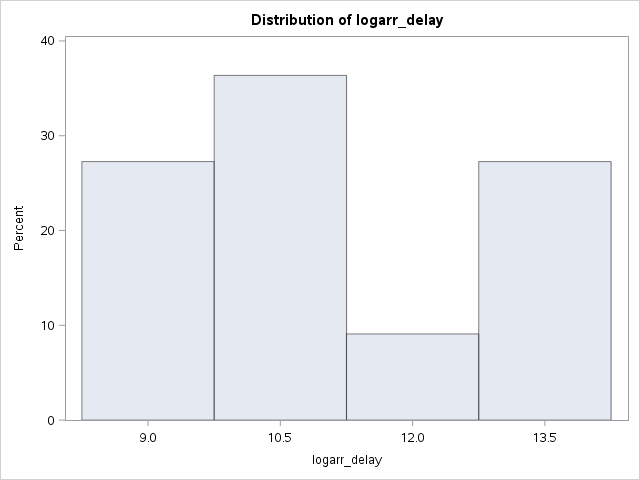

The UNIVARIATE Procedure

IATA_CODE=JFK

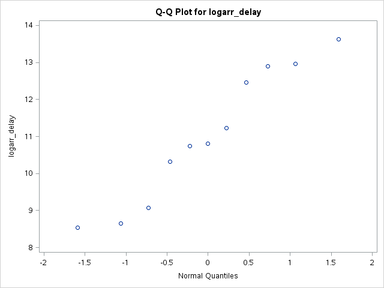

The UNIVARIATE Procedure

Variable: arr_delay (arr_delay)

IATA_CODE=LAS

| Moments |  |  |  |
| --- | --- | --- | --- |
| N | 12 | Sum Weights | 12 |
| Mean | 137664.75 | Sum Observations | 1651977 |
| Std Deviation | 159103.75 | Variance | 2.5314E10 |
| Skewness | 2.50284525 | Kurtosis | 7.42521716 |
| Uncorrected SS | 5.05873E11 | Corrected SS | 2.78454E11 |
| Coeff Variation | 115.57334 | Std Error Mean | 45929.2963 |

| Basic Statistical Measures Location | Basic Statistical Measures Location | Basic Statistical Measures Variability | Basic Statistical Measures Variability |
| --- | --- | --- | --- |
| Mean | 137664.8 | Std Deviation | 159104 |
| Median | 113894.5 | Variance | 2.5314E10 |
| Mode | . | Range | 593853 |
|  |  | Interquartile Range | 120401 |

| Tests for Location: Mu0=0 Test | Tests for Location: Mu0=0 Statistic | Tests for Location: Mu0=0 Statistic | Tests for Location: Mu0=0 p Value | Tests for Location: Mu0=0 p Value |
| --- | --- | --- | --- | --- |
| Student's t | t | 2.997319 | Pr > \|t\| | 0.0121 |
| Sign | M | 6 | Pr >= \|M\| | 0.0005 |
| Signed Rank | S | 39 | Pr >= \|S\| | 0.0005 |

| Quantiles (Definition 5) Level | Quantiles (Definition 5) Quantile |
| --- | --- |
| 100% Max | 600317.0 |
| 99% | 600317.0 |
| 95% | 600317.0 |
| 90% | 176403.0 |
| 75% Q3 | 165441.0 |
| 50% Median | 113894.5 |
| 25% Q1 | 45040.5 |
| 10% | 9912.0 |
| 5% | 6464.0 |
| 1% | 6464.0 |
| 0% Min | 6464.0 |

| Extreme Observations Lowest Value | Extreme Observations Lowest Obs | Extreme Observations Highest Value | Extreme Observations Highest Obs |
| --- | --- | --- | --- |
| 6464 | 169 | 153417 | 168 |
| 9912 | 173 | 161231 | 167 |
| 33909 | 171 | 169651 | 163 |
| 56172 | 165 | 176403 | 170 |
| 56712 | 164 | 600317 | 174 |

The UNIVARIATE Procedure

Variable: logarr_delay

IATA_CODE=LAS

| Moments |  |  |  |
| --- | --- | --- | --- |
| N | 12 | Sum Weights | 12 |
| Mean | 11.2361856 | Sum Observations | 134.834227 |
| Std Deviation | 1.28592436 | Variance | 1.65360146 |
| Skewness | -0.6594589 | Kurtosis | 0.25175071 |
| Uncorrected SS | 1533.21201 | Corrected SS | 18.1896161 |
| Coeff Variation | 11.444492 | Std Error Mean | 0.37121439 |

| Basic Statistical Measures Location | Basic Statistical Measures Location | Basic Statistical Measures Variability | Basic Statistical Measures Variability |
| --- | --- | --- | --- |
| Mean | 11.23619 | Std Deviation | 1.28592 |
| Median | 11.59331 | Variance | 1.65360 |
| Mode | . | Range | 4.53121 |
|  |  | Interquartile Range | 1.33224 |

| Tests for Location: Mu0=0 Test | Tests for Location: Mu0=0 Statistic | Tests for Location: Mu0=0 Statistic | Tests for Location: Mu0=0 p Value | Tests for Location: Mu0=0 p Value |
| --- | --- | --- | --- | --- |
| Student's t | t | 30.26872 | Pr > \|t\| | <.0001 |
| Sign | M | 6 | Pr >= \|M\| | 0.0005 |
| Signed Rank | S | 39 | Pr >= \|S\| | 0.0005 |

| Quantiles (Definition 5) Level | Quantiles (Definition 5) Quantile |
| --- | --- |
| 100% Max | 13.3052 |
| 99% | 13.3052 |
| 95% | 13.3052 |
| 90% | 12.0805 |
| 75% Q3 | 12.0160 |
| 50% Median | 11.5933 |
| 25% Q1 | 10.6838 |
| 10% | 9.2015 |
| 5% | 8.7740 |
| 1% | 8.7740 |
| 0% Min | 8.7740 |

| Extreme Observations Lowest Value | Extreme Observations Lowest Obs | Extreme Observations Highest Value | Extreme Observations Highest Obs |
| --- | --- | --- | --- |
| 8.7740 | 169 | 11.9409 | 168 |
| 9.2015 | 173 | 11.9906 | 167 |
| 10.4314 | 171 | 12.0415 | 163 |
| 10.9362 | 165 | 12.0805 | 170 |
| 10.9457 | 164 | 13.3052 | 174 |

The UNIVARIATE Procedure

IATA_CODE=LAS

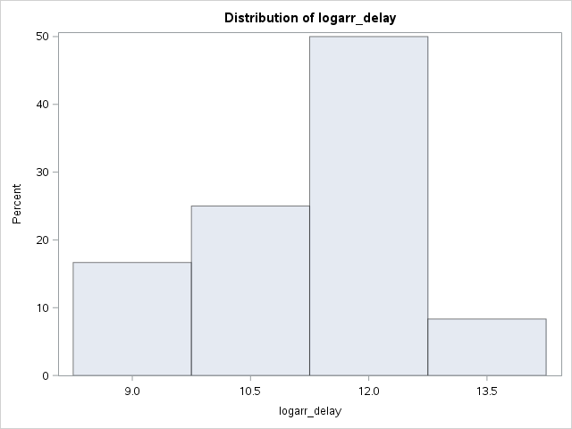

The UNIVARIATE Procedure

IATA_CODE=LAS

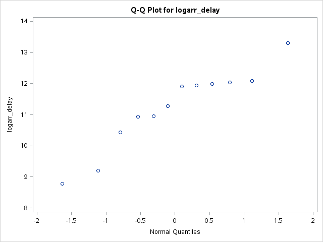

The UNIVARIATE Procedure

Variable: arr_delay (arr_delay)

IATA_CODE=LAX

| Moments |  |  |  |
| --- | --- | --- | --- |
| N | 12 | Sum Weights | 12 |
| Mean | 193570.667 | Sum Observations | 2322848 |
| Std Deviation | 173476.452 | Variance | 3.00941E10 |
| Skewness | 0.4378827 | Kurtosis | -1.6635238 |
| Uncorrected SS | 7.8067E11 | Corrected SS | 3.31035E11 |
| Coeff Variation | 89.6191842 | Std Error Mean | 50078.3382 |

| Basic Statistical Measures Location | Basic Statistical Measures Location | Basic Statistical Measures Variability | Basic Statistical Measures Variability |
| --- | --- | --- | --- |
| Mean | 193570.7 | Std Deviation | 173476 |
| Median | 120754.5 | Variance | 3.00941E10 |
| Mode | . | Range | 450478 |
|  |  | Interquartile Range | 323427 |

| Tests for Location: Mu0=0 Test | Tests for Location: Mu0=0 Statistic | Tests for Location: Mu0=0 Statistic | Tests for Location: Mu0=0 p Value | Tests for Location: Mu0=0 p Value |
| --- | --- | --- | --- | --- |
| Student's t | t | 3.865357 | Pr > \|t\| | 0.0026 |
| Sign | M | 6 | Pr >= \|M\| | 0.0005 |
| Signed Rank | S | 39 | Pr >= \|S\| | 0.0005 |

| Quantiles (Definition 5) Level | Quantiles (Definition 5) Quantile |
| --- | --- |
| 100% Max | 469109 |
| 99% | 469109 |
| 95% | 469109 |
| 90% | 415672 |
| 75% Q3 | 352138 |
| 50% Median | 120755 |
| 25% Q1 | 28711 |
| 10% | 25084 |
| 5% | 18631 |
| 1% | 18631 |
| 0% Min | 18631 |

| Extreme Observations Lowest Value | Extreme Observations Lowest Obs | Extreme Observations Highest Value | Extreme Observations Highest Obs |
| --- | --- | --- | --- |
| 18631 | 179 | 309112 | 184 |
| 25084 | 181 | 313421 | 178 |
| 26533 | 180 | 390854 | 183 |
| 30889 | 185 | 415672 | 175 |
| 82034 | 177 | 469109 | 186 |

The UNIVARIATE Procedure

Variable: logarr_delay

IATA_CODE=LAX

| Moments |  |  |  |
| --- | --- | --- | --- |
| N | 12 | Sum Weights | 12 |
| Mean | 11.6062473 | Sum Observations | 139.274968 |
| Std Deviation | 1.23975057 | Variance | 1.53698148 |
| Skewness | -0.2268282 | Kurtosis | -1.7733882 |
| Uncorrected SS | 1633.36652 | Corrected SS | 16.9067962 |
| Coeff Variation | 10.6817521 | Std Error Mean | 0.35788516 |

| Basic Statistical Measures Location | Basic Statistical Measures Location | Basic Statistical Measures Variability | Basic Statistical Measures Variability |
| --- | --- | --- | --- |
| Mean | 11.60625 | Std Deviation | 1.23975 |
| Median | 11.65206 | Variance | 1.53698 |
| Mode | . | Range | 3.22601 |
|  |  | Interquartile Range | 2.50355 |

| Tests for Location: Mu0=0 Test | Tests for Location: Mu0=0 Statistic | Tests for Location: Mu0=0 Statistic | Tests for Location: Mu0=0 p Value | Tests for Location: Mu0=0 p Value |
| --- | --- | --- | --- | --- |
| Student's t | t | 32.43009 | Pr > \|t\| | <.0001 |
| Sign | M | 6 | Pr >= \|M\| | 0.0005 |
| Signed Rank | S | 39 | Pr >= \|S\| | 0.0005 |

| Quantiles (Definition 5) Level | Quantiles (Definition 5) Quantile |
| --- | --- |
| 100% Max | 13.05859 |
| 99% | 13.05859 |
| 95% | 13.05859 |
| 90% | 12.93765 |
| 75% Q3 | 12.76570 |
| 50% Median | 11.65206 |
| 25% Q1 | 10.26215 |
| 10% | 10.12999 |
| 5% | 9.83258 |
| 1% | 9.83258 |
| 0% Min | 9.83258 |

| Extreme Observations Lowest Value | Extreme Observations Lowest Obs | Extreme Observations Highest Value | Extreme Observations Highest Obs |
| --- | --- | --- | --- |
| 9.83258 | 179 | 12.6415 | 184 |
| 10.12999 | 181 | 12.6553 | 178 |
| 10.18614 | 180 | 12.8761 | 183 |
| 10.33816 | 185 | 12.9377 | 175 |
| 11.31489 | 177 | 13.0586 | 186 |

The UNIVARIATE Procedure

IATA_CODE=LAX

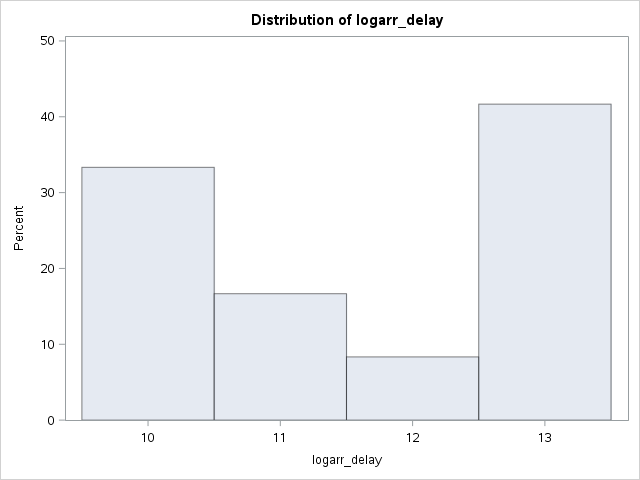

The UNIVARIATE Procedure

IATA_CODE=LAX

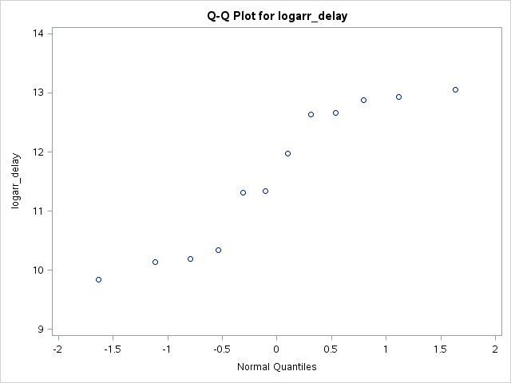

The UNIVARIATE Procedure

Variable: arr_delay (arr_delay)

IATA_CODE=LGA

| Moments |  |  |  |
| --- | --- | --- | --- |
| N | 14 | Sum Weights | 14 |
| Mean | 211777.286 | Sum Observations | 2964882 |
| Std Deviation | 170835.627 | Variance | 2.91848E10 |
| Skewness | 0.89048727 | Kurtosis | -0.035047 |
| Uncorrected SS | 1.0073E12 | Corrected SS | 3.79403E11 |
| Coeff Variation | 80.6675875 | Std Error Mean | 45657.7419 |

| Basic Statistical Measures Location | Basic Statistical Measures Location | Basic Statistical Measures Variability | Basic Statistical Measures Variability |
| --- | --- | --- | --- |
| Mean | 211777.3 | Std Deviation | 170836 |
| Median | 165126.0 | Variance | 2.91848E10 |
| Mode | . | Range | 529247 |
|  |  | Interquartile Range | 229159 |

| Tests for Location: Mu0=0 Test | Tests for Location: Mu0=0 Statistic | Tests for Location: Mu0=0 Statistic | Tests for Location: Mu0=0 p Value | Tests for Location: Mu0=0 p Value |
| --- | --- | --- | --- | --- |
| Student's t | t | 4.638365 | Pr > \|t\| | 0.0005 |
| Sign | M | 7 | Pr >= \|M\| | 0.0001 |
| Signed Rank | S | 52.5 | Pr >= \|S\| | 0.0001 |

| Quantiles (Definition 5) Level | Quantiles (Definition 5) Quantile |
| --- | --- |
| 100% Max | 549507 |
| 99% | 549507 |
| 95% | 549507 |
| 90% | 519495 |
| 75% Q3 | 292805 |
| 50% Median | 165126 |
| 25% Q1 | 63646 |
| 10% | 28898 |
| 5% | 20260 |
| 1% | 20260 |
| 0% Min | 20260 |

| Extreme Observations Lowest Value | Extreme Observations Lowest Obs | Extreme Observations Highest Value | Extreme Observations Highest Obs |
| --- | --- | --- | --- |
| 20260 | 192 | 272555 | 193 |
| 28898 | 199 | 292805 | 188 |
| 38949 | 195 | 364980 | 190 |
| 63646 | 194 | 519495 | 200 |
| 133601 | 189 | 549507 | 187 |

The UNIVARIATE Procedure

Variable: logarr_delay

IATA_CODE=LGA

| Moments |  |  |  |
| --- | --- | --- | --- |
| N | 14 | Sum Weights | 14 |
| Mean | 11.8609145 | Sum Observations | 166.052803 |
| Std Deviation | 1.04448047 | Variance | 1.09093945 |
| Skewness | -0.6121625 | Kurtosis | -0.6140322 |
| Uncorrected SS | 1983.72031 | Corrected SS | 14.1822128 |
| Coeff Variation | 8.80607028 | Std Error Mean | 0.27914915 |

| Basic Statistical Measures Location | Basic Statistical Measures Location | Basic Statistical Measures Variability | Basic Statistical Measures Variability |
| --- | --- | --- | --- |
| Mean | 11.86091 | Std Deviation | 1.04448 |
| Median | 12.01265 | Variance | 1.09094 |
| Mode | . | Range | 3.30037 |
|  |  | Interquartile Range | 1.52617 |

| Tests for Location: Mu0=0 Test | Tests for Location: Mu0=0 Statistic | Tests for Location: Mu0=0 Statistic | Tests for Location: Mu0=0 p Value | Tests for Location: Mu0=0 p Value |
| --- | --- | --- | --- | --- |
| Student's t | t | 42.48952 | Pr > \|t\| | <.0001 |
| Sign | M | 7 | Pr >= \|M\| | 0.0001 |
| Signed Rank | S | 52.5 | Pr >= \|S\| | 0.0001 |

| Quantiles (Definition 5) Level | Quantiles (Definition 5) Quantile |
| --- | --- |
| 100% Max | 13.2168 |
| 99% | 13.2168 |
| 95% | 13.2168 |
| 90% | 13.1606 |
| 75% Q3 | 12.5873 |
| 50% Median | 12.0126 |
| 25% Q1 | 11.0611 |
| 10% | 10.2715 |
| 5% | 9.9164 |
| 1% | 9.9164 |
| 0% Min | 9.9164 |

| Extreme Observations Lowest Value | Extreme Observations Lowest Obs | Extreme Observations Highest Value | Extreme Observations Highest Obs |
| --- | --- | --- | --- |
| 9.9164 | 192 | 12.5156 | 193 |
| 10.2715 | 199 | 12.5873 | 188 |
| 10.5700 | 195 | 12.8076 | 190 |
| 11.0611 | 194 | 13.1606 | 200 |
| 11.8026 | 189 | 13.2168 | 187 |

The UNIVARIATE Procedure

IATA_CODE=LGA

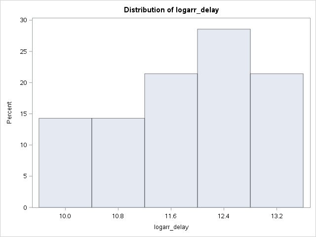

The UNIVARIATE Procedure

IATA_CODE=LGA

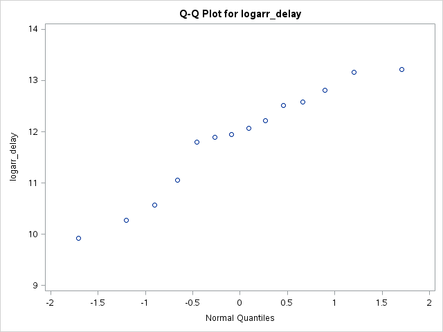

The UNIVARIATE Procedure

Variable: arr_delay (arr_delay)

IATA_CODE=MCO

| Moments |  |  |  |
| --- | --- | --- | --- |
| N | 13 | Sum Weights | 13 |
| Mean | 143540.846 | Sum Observations | 1866031 |
| Std Deviation | 157693.339 | Variance | 2.48672E10 |
| Skewness | 0.7399601 | Kurtosis | -0.5266667 |
| Uncorrected SS | 5.66258E11 | Corrected SS | 2.98406E11 |
| Coeff Variation | 109.859558 | Std Error Mean | 43736.2631 |

| Basic Statistical Measures Location | Basic Statistical Measures Location | Basic Statistical Measures Variability | Basic Statistical Measures Variability |
| --- | --- | --- | --- |
| Mean | 143540.8 | Std Deviation | 157693 |
| Median | 153995.0 | Variance | 2.48672E10 |
| Mode | . | Range | 452481 |
|  |  | Interquartile Range | 227630 |

| Tests for Location: Mu0=0 Test | Tests for Location: Mu0=0 Statistic | Tests for Location: Mu0=0 Statistic | Tests for Location: Mu0=0 p Value | Tests for Location: Mu0=0 p Value |
| --- | --- | --- | --- | --- |
| Student's t | t | 3.281964 | Pr > \|t\| | 0.0066 |
| Sign | M | 6.5 | Pr >= \|M\| | 0.0002 |
| Signed Rank | S | 45.5 | Pr >= \|S\| | 0.0002 |

| Quantiles (Definition 5) Level | Quantiles (Definition 5) Quantile |
| --- | --- |
| 100% Max | 452713 |
| 99% | 452713 |
| 95% | 452713 |
| 90% | 386471 |
| 75% Q3 | 228792 |
| 50% Median | 153995 |
| 25% Q1 | 1162 |
| 10% | 250 |
| 5% | 232 |
| 1% | 232 |
| 0% Min | 232 |

| Extreme Observations Lowest Value | Extreme Observations Lowest Obs | Extreme Observations Highest Value | Extreme Observations Highest Obs |
| --- | --- | --- | --- |
| 232 | 213 | 186686 | 208 |
| 250 | 206 | 228792 | 202 |
| 465 | 209 | 261877 | 207 |
| 1162 | 211 | 386471 | 204 |
| 1965 | 201 | 452713 | 212 |

The UNIVARIATE Procedure

Variable: logarr_delay

IATA_CODE=MCO

| Moments |  |  |  |
| --- | --- | --- | --- |
| N | 13 | Sum Weights | 13 |
| Mean | 9.84617367 | Sum Observations | 128.000258 |
| Std Deviation | 3.05473812 | Variance | 9.33142497 |
| Skewness | -0.4293299 | Kurtosis | -1.7998851 |
| Uncorrected SS | 1372.28987 | Corrected SS | 111.9771 |
| Coeff Variation | 31.0246216 | Std Error Mean | 0.84723192 |

| Basic Statistical Measures Location | Basic Statistical Measures Location | Basic Statistical Measures Variability | Basic Statistical Measures Variability |
| --- | --- | --- | --- |
| Mean | 9.84617 | Std Deviation | 3.05474 |
| Median | 11.94468 | Variance | 9.33142 |
| Mode | . | Range | 7.57628 |
|  |  | Interquartile Range | 5.28267 |

| Tests for Location: Mu0=0 Test | Tests for Location: Mu0=0 Statistic | Tests for Location: Mu0=0 Statistic | Tests for Location: Mu0=0 p Value | Tests for Location: Mu0=0 p Value |
| --- | --- | --- | --- | --- |
| Student's t | t | 11.62158 | Pr > \|t\| | <.0001 |
| Sign | M | 6.5 | Pr >= \|M\| | 0.0002 |
| Signed Rank | S | 45.5 | Pr >= \|S\| | 0.0002 |

| Quantiles (Definition 5) Level | Quantiles (Definition 5) Quantile |
| --- | --- |
| 100% Max | 13.02301 |
| 99% | 13.02301 |
| 95% | 13.02301 |
| 90% | 12.86481 |
| 75% Q3 | 12.34057 |
| 50% Median | 11.94468 |
| 25% Q1 | 7.05790 |
| 10% | 5.52146 |
| 5% | 5.44674 |
| 1% | 5.44674 |
| 0% Min | 5.44674 |

| Extreme Observations Lowest Value | Extreme Observations Lowest Obs | Extreme Observations Highest Value | Extreme Observations Highest Obs |
| --- | --- | --- | --- |
| 5.44674 | 213 | 12.1372 | 208 |
| 5.52146 | 206 | 12.3406 | 202 |
| 6.14204 | 209 | 12.4756 | 207 |
| 7.05790 | 211 | 12.8648 | 204 |
| 7.58325 | 201 | 13.0230 | 212 |

The UNIVARIATE Procedure

IATA_CODE=MCO

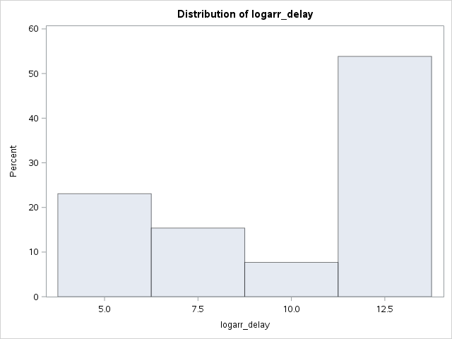

The UNIVARIATE Procedure

IATA_CODE=MCO

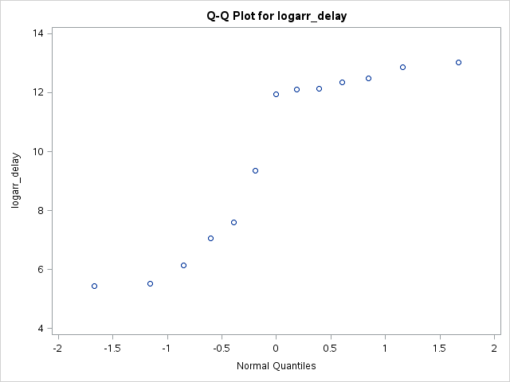

The UNIVARIATE Procedure

Variable: arr_delay (arr_delay)

IATA_CODE=MDW

| Moments |  |  |  |
| --- | --- | --- | --- |
| N | 4 | Sum Weights | 4 |
| Mean | 197760 | Sum Observations | 791040 |
| Std Deviation | 360882.304 | Variance | 1.30236E11 |
| Skewness | 1.99250993 | Kurtosis | 3.97495641 |
| Uncorrected SS | 5.47144E11 | Corrected SS | 3.90708E11 |
| Coeff Variation | 182.484984 | Std Error Mean | 180441.152 |

| Basic Statistical Measures Location | Basic Statistical Measures Location | Basic Statistical Measures Variability | Basic Statistical Measures Variability |
| --- | --- | --- | --- |
| Mean | 197760.0 | Std Deviation | 360882 |
| Median | 25073.0 | Variance | 1.30236E11 |
| Mode | . | Range | 736596 |
|  |  | Interquartile Range | 376607 |

| Tests for Location: Mu0=0 Test | Tests for Location: Mu0=0 Statistic | Tests for Location: Mu0=0 Statistic | Tests for Location: Mu0=0 p Value | Tests for Location: Mu0=0 p Value |
| --- | --- | --- | --- | --- |
| Student's t | t | 1.095981 | Pr > \|t\| | 0.3532 |
| Sign | M | 2 | Pr >= \|M\| | 0.1250 |
| Signed Rank | S | 5 | Pr >= \|S\| | 0.1250 |

| Quantiles (Definition 5) Level | Quantiles (Definition 5) Quantile |
| --- | --- |
| 100% Max | 738745.0 |
| 99% | 738745.0 |
| 95% | 738745.0 |
| 90% | 738745.0 |
| 75% Q3 | 386063.5 |
| 50% Median | 25073.0 |
| 25% Q1 | 9456.5 |
| 10% | 2149.0 |
| 5% | 2149.0 |
| 1% | 2149.0 |
| 0% Min | 2149.0 |

| Extreme Observations Lowest Value | Extreme Observations Lowest Obs | Extreme Observations Highest Value | Extreme Observations Highest Obs |
| --- | --- | --- | --- |
| 2149 | 215 | 2149 | 215 |
| 16764 | 214 | 16764 | 214 |
| 33382 | 216 | 33382 | 216 |
| 738745 | 217 | 738745 | 217 |

The UNIVARIATE Procedure

Variable: logarr_delay

IATA_CODE=MDW

| Moments |  |  |  |
| --- | --- | --- | --- |
| N | 4 | Sum Weights | 4 |
| Mean | 10.3320568 | Sum Observations | 41.3282271 |
| Std Deviation | 2.4194716 | Variance | 5.85384283 |
| Skewness | 0.61897681 | Kurtosis | 1.3332949 |
| Uncorrected SS | 444.567117 | Corrected SS | 17.5615285 |
| Coeff Variation | 23.4171342 | Std Error Mean | 1.2097358 |

| Basic Statistical Measures Location | Basic Statistical Measures Location | Basic Statistical Measures Variability | Basic Statistical Measures Variability |
| --- | --- | --- | --- |
| Mean | 10.33206 | Std Deviation | 2.41947 |
| Median | 10.07138 | Variance | 5.85384 |
| Mode | . | Range | 5.83995 |
|  |  | Interquartile Range | 3.26437 |

| Tests for Location: Mu0=0 Test | Tests for Location: Mu0=0 Statistic | Tests for Location: Mu0=0 Statistic | Tests for Location: Mu0=0 p Value | Tests for Location: Mu0=0 p Value |
| --- | --- | --- | --- | --- |
| Student's t | t | 8.540755 | Pr > \|t\| | 0.0034 |
| Sign | M | 2 | Pr >= \|M\| | 0.1250 |
| Signed Rank | S | 5 | Pr >= \|S\| | 0.1250 |

| Quantiles (Definition 5) Level | Quantiles (Definition 5) Quantile |
| --- | --- |
| 100% Max | 13.51271 |
| 99% | 13.51271 |
| 95% | 13.51271 |
| 90% | 13.51271 |
| 75% Q3 | 11.96424 |
| 50% Median | 10.07138 |
| 25% Q1 | 8.69987 |
| 10% | 7.67276 |
| 5% | 7.67276 |
| 1% | 7.67276 |
| 0% Min | 7.67276 |

| Extreme Observations Lowest Value | Extreme Observations Lowest Obs | Extreme Observations Highest Value | Extreme Observations Highest Obs |
| --- | --- | --- | --- |
| 7.67276 | 215 | 7.67276 | 215 |
| 9.72699 | 214 | 9.72699 | 214 |
| 10.41577 | 216 | 10.41577 | 216 |
| 13.51271 | 217 | 13.51271 | 217 |

The UNIVARIATE Procedure

IATA_CODE=MDW

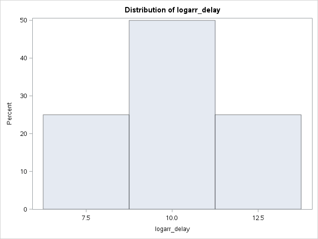

The UNIVARIATE Procedure

IATA_CODE=MDW

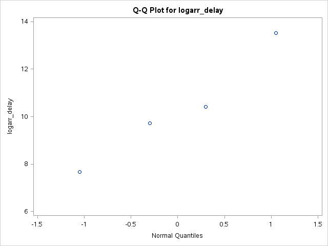

The UNIVARIATE Procedure

Variable: arr_delay (arr_delay)

IATA_CODE=MIA

| Moments |  |  |  |
| --- | --- | --- | --- |
| N | 8 | Sum Weights | 8 |
| Mean | 132652.75 | Sum Observations | 1061222 |
| Std Deviation | 225957.237 | Variance | 5.10567E10 |
| Skewness | 2.64126312 | Kurtosis | 7.21940843 |
| Uncorrected SS | 4.98171E11 | Corrected SS | 3.57397E11 |
| Coeff Variation | 170.337393 | Std Error Mean | 79887.9472 |

| Basic Statistical Measures Location | Basic Statistical Measures Location | Basic Statistical Measures Variability | Basic Statistical Measures Variability |
| --- | --- | --- | --- |
| Mean | 132652.8 | Std Deviation | 225957 |
| Median | 71294.0 | Variance | 5.10567E10 |
| Mode | . | Range | 682298 |
|  |  | Interquartile Range | 86023 |

| Tests for Location: Mu0=0 Test | Tests for Location: Mu0=0 Statistic | Tests for Location: Mu0=0 Statistic | Tests for Location: Mu0=0 p Value | Tests for Location: Mu0=0 p Value |
| --- | --- | --- | --- | --- |
| Student's t | t | 1.660485 | Pr > \|t\| | 0.1408 |
| Sign | M | 4 | Pr >= \|M\| | 0.0078 |
| Signed Rank | S | 18 | Pr >= \|S\| | 0.0078 |

| Quantiles (Definition 5) Level | Quantiles (Definition 5) Quantile |
| --- | --- |
| 100% Max | 682481 |
| 99% | 682481 |
| 95% | 682481 |
| 90% | 682481 |
| 75% Q3 | 102004 |
| 50% Median | 71294 |
| 25% Q1 | 15981 |
| 10% | 183 |
| 5% | 183 |
| 1% | 183 |
| 0% Min | 183 |

| Extreme Observations Lowest Value | Extreme Observations Lowest Obs | Extreme Observations Highest Value | Extreme Observations Highest Obs |
| --- | --- | --- | --- |
| 183 | 218 | 60804 | 223 |
| 664 | 224 | 81784 | 225 |
| 31298 | 221 | 91636 | 220 |
| 60804 | 223 | 112372 | 222 |
| 81784 | 225 | 682481 | 219 |

The UNIVARIATE Procedure

Variable: logarr_delay

IATA_CODE=MIA

| Moments |  |  |  |
| --- | --- | --- | --- |
| N | 8 | Sum Weights | 8 |
| Mean | 10.1093706 | Sum Observations | 80.8749651 |
| Std Deviation | 2.78945406 | Variance | 7.78105397 |
| Skewness | -1.0505278 | Kurtosis | 0.08147497 |
| Uncorrected SS | 872.062375 | Corrected SS | 54.4673778 |
| Coeff Variation | 27.5927569 | Std Error Mean | 0.98622094 |

| Basic Statistical Measures Location | Basic Statistical Measures Location | Basic Statistical Measures Variability | Basic Statistical Measures Variability |
| --- | --- | --- | --- |
| Mean | 10.10937 | Std Deviation | 2.78945 |
| Median | 11.16362 | Variance | 7.78105 |
| Mode | . | Range | 8.22400 |
|  |  | Interquartile Range | 3.10278 |

| Tests for Location: Mu0=0 Test | Tests for Location: Mu0=0 Statistic | Tests for Location: Mu0=0 Statistic | Tests for Location: Mu0=0 p Value | Tests for Location: Mu0=0 p Value |
| --- | --- | --- | --- | --- |
| Student's t | t | 10.25061 | Pr > \|t\| | <.0001 |
| Sign | M | 4 | Pr >= \|M\| | 0.0078 |
| Signed Rank | S | 18 | Pr >= \|S\| | 0.0078 |

| Quantiles (Definition 5) Level | Quantiles (Definition 5) Quantile |
| --- | --- |
| 100% Max | 13.43349 |
| 99% | 13.43349 |
| 95% | 13.43349 |
| 90% | 13.43349 |
| 75% Q3 | 11.52757 |
| 50% Median | 11.16362 |
| 25% Q1 | 8.42480 |
| 10% | 5.20949 |
| 5% | 5.20949 |
| 1% | 5.20949 |
| 0% Min | 5.20949 |

| Extreme Observations Lowest Value | Extreme Observations Lowest Obs | Extreme Observations Highest Value | Extreme Observations Highest Obs |
| --- | --- | --- | --- |
| 5.20949 | 218 | 11.0154 | 223 |
| 6.49828 | 224 | 11.3118 | 225 |
| 10.35131 | 221 | 11.4256 | 220 |
| 11.01541 | 223 | 11.6296 | 222 |
| 11.31184 | 225 | 13.4335 | 219 |

The UNIVARIATE Procedure

IATA_CODE=MIA

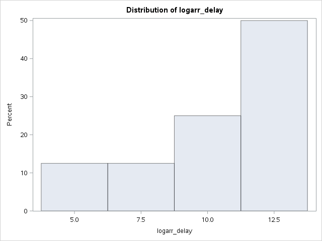

The UNIVARIATE Procedure

IATA_CODE=MIA

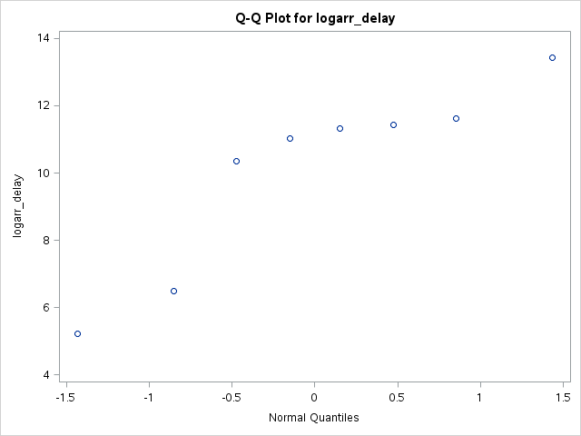

The UNIVARIATE Procedure

Variable: arr_delay (arr_delay)

IATA_CODE=MSP

| Moments |  |  |  |
| --- | --- | --- | --- |
| N | 15 | Sum Weights | 15 |
| Mean | 111783.067 | Sum Observations | 1676746 |
| Std Deviation | 190534.442 | Variance | 3.63034E10 |
| Skewness | 2.25406055 | Kurtosis | 3.9786679 |
| Uncorrected SS | 6.95679E11 | Corrected SS | 5.08247E11 |
| Coeff Variation | 170.450183 | Std Error Mean | 49195.7814 |

| Basic Statistical Measures Location | Basic Statistical Measures Location | Basic Statistical Measures Variability | Basic Statistical Measures Variability |
| --- | --- | --- | --- |
| Mean | 111783.1 | Std Deviation | 190534 |
| Median | 45804.0 | Variance | 3.63034E10 |
| Mode | . | Range | 606081 |
|  |  | Interquartile Range | 73240 |

| Tests for Location: Mu0=0 Test | Tests for Location: Mu0=0 Statistic | Tests for Location: Mu0=0 Statistic | Tests for Location: Mu0=0 p Value | Tests for Location: Mu0=0 p Value |
| --- | --- | --- | --- | --- |
| Student's t | t | 2.272208 | Pr > \|t\| | 0.0394 |
| Sign | M | 7.5 | Pr >= \|M\| | <.0001 |
| Signed Rank | S | 60 | Pr >= \|S\| | <.0001 |

| Quantiles (Definition 5) Level | Quantiles (Definition 5) Quantile |
| --- | --- |
| 100% Max | 607122 |
| 99% | 607122 |
| 95% | 607122 |
| 90% | 534534 |
| 75% Q3 | 84861 |
| 50% Median | 45804 |
| 25% Q1 | 11621 |
| 10% | 2209 |
| 5% | 1041 |
| 1% | 1041 |
| 0% Min | 1041 |

| Extreme Observations Lowest Value | Extreme Observations Lowest Obs | Extreme Observations Highest Value | Extreme Observations Highest Obs |
| --- | --- | --- | --- |
| 1041 | 235 | 83671 | 238 |
| 2209 | 233 | 84861 | 227 |
| 4367 | 228 | 135089 | 226 |
| 11621 | 229 | 534534 | 230 |
| 12550 | 231 | 607122 | 236 |

The UNIVARIATE Procedure

Variable: logarr_delay

IATA_CODE=MSP

| Moments |  |  |  |
| --- | --- | --- | --- |
| N | 15 | Sum Weights | 15 |
| Mean | 10.3719629 | Sum Observations | 155.579443 |
| Std Deviation | 1.81137014 | Variance | 3.28106177 |
| Skewness | -0.2226028 | Kurtosis | -0.1938782 |
| Uncorrected SS | 1659.59908 | Corrected SS | 45.9348647 |
| Coeff Variation | 17.4641016 | Std Error Mean | 0.46769376 |

| Basic Statistical Measures Location | Basic Statistical Measures Location | Basic Statistical Measures Variability | Basic Statistical Measures Variability |
| --- | --- | --- | --- |
| Mean | 10.37196 | Std Deviation | 1.81137 |
| Median | 10.73213 | Variance | 3.28106 |
| Mode | . | Range | 6.36855 |
|  |  | Interquartile Range | 1.98820 |

| Tests for Location: Mu0=0 Test | Tests for Location: Mu0=0 Statistic | Tests for Location: Mu0=0 Statistic | Tests for Location: Mu0=0 p Value | Tests for Location: Mu0=0 p Value |
| --- | --- | --- | --- | --- |
| Student's t | t | 22.17683 | Pr > \|t\| | <.0001 |
| Sign | M | 7.5 | Pr >= \|M\| | <.0001 |
| Signed Rank | S | 60 | Pr >= \|S\| | <.0001 |

| Quantiles (Definition 5) Level | Quantiles (Definition 5) Quantile |
| --- | --- |
| 100% Max | 13.31649 |
| 99% | 13.31649 |
| 95% | 13.31649 |
| 90% | 13.18915 |
| 75% Q3 | 11.34877 |
| 50% Median | 10.73213 |
| 25% Q1 | 9.36057 |
| 10% | 7.70030 |
| 5% | 6.94794 |
| 1% | 6.94794 |
| 0% Min | 6.94794 |

| Extreme Observations Lowest Value | Extreme Observations Lowest Obs | Extreme Observations Highest Value | Extreme Observations Highest Obs |
| --- | --- | --- | --- |
| 6.94794 | 235 | 11.3346 | 238 |
| 7.70030 | 233 | 11.3488 | 227 |
| 8.38183 | 228 | 11.8137 | 226 |
| 9.36057 | 229 | 13.1892 | 230 |
| 9.43748 | 231 | 13.3165 | 236 |

The UNIVARIATE Procedure

IATA_CODE=MSP

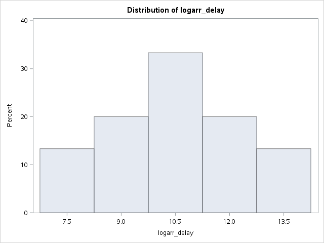

The UNIVARIATE Procedure

IATA_CODE=MSP

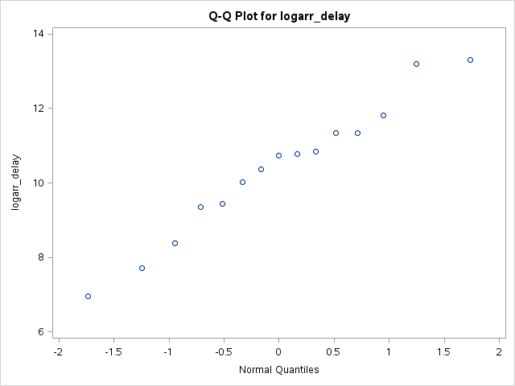

The UNIVARIATE Procedure

Variable: arr_delay (arr_delay)

IATA_CODE=ORD

| Moments |  |  |  |
| --- | --- | --- | --- |
| N | 14 | Sum Weights | 14 |
| Mean | 373918.214 | Sum Observations | 5234855 |
| Std Deviation | 488462.562 | Variance | 2.38596E11 |
| Skewness | 1.46622492 | Kurtosis | 1.18331346 |
| Uncorrected SS | 5.05915E12 | Corrected SS | 3.10174E12 |
| Coeff Variation | 130.63353 | Std Error Mean | 130547.111 |

| Basic Statistical Measures Location | Basic Statistical Measures Location | Basic Statistical Measures Variability | Basic Statistical Measures Variability |
| --- | --- | --- | --- |
| Mean | 373918.2 | Std Deviation | 488463 |
| Median | 148610.5 | Variance | 2.38596E11 |
| Mode | . | Range | 1549177 |
|  |  | Interquartile Range | 760893 |

| Tests for Location: Mu0=0 Test | Tests for Location: Mu0=0 Statistic | Tests for Location: Mu0=0 Statistic | Tests for Location: Mu0=0 p Value | Tests for Location: Mu0=0 p Value |
| --- | --- | --- | --- | --- |
| Student's t | t | 2.86424 | Pr > \|t\| | 0.0133 |
| Sign | M | 7 | Pr >= \|M\| | 0.0001 |
| Signed Rank | S | 52.5 | Pr >= \|S\| | 0.0001 |

| Quantiles (Definition 5) Level | Quantiles (Definition 5) Quantile |
| --- | --- |
| 100% Max | 1551409 |
| 99% | 1551409 |
| 95% | 1551409 |
| 90% | 1085912 |
| 75% Q3 | 796579 |
| 50% Median | 148611 |
| 25% Q1 | 35686 |
| 10% | 31986 |
| 5% | 2232 |
| 1% | 2232 |
| 0% Min | 2232 |

| Extreme Observations Lowest Value | Extreme Observations Lowest Obs | Extreme Observations Highest Value | Extreme Observations Highest Obs |
| --- | --- | --- | --- |
| 2232 | 253 | 224132 | 254 |
| 31986 | 243 | 796579 | 248 |
| 33026 | 250 | 827469 | 242 |
| 35686 | 241 | 1085912 | 252 |
| 63945 | 244 | 1551409 | 251 |

The UNIVARIATE Procedure

Variable: logarr_delay

IATA_CODE=ORD

| Moments |  |  |  |
| --- | --- | --- | --- |
| N | 14 | Sum Weights | 14 |
| Mean | 11.7827187 | Sum Observations | 164.958061 |
| Std Deviation | 1.77406496 | Variance | 3.14730646 |
| Skewness | -0.6230146 | Kurtosis | 0.67433013 |
| Uncorrected SS | 1984.56941 | Corrected SS | 40.914984 |
| Coeff Variation | 15.0564993 | Std Error Mean | 0.4741388 |

| Basic Statistical Measures Location | Basic Statistical Measures Location | Basic Statistical Measures Variability | Basic Statistical Measures Variability |
| --- | --- | --- | --- |
| Mean | 11.78272 | Std Deviation | 1.77406 |
| Median | 11.90489 | Variance | 3.14731 |
| Mode | . | Range | 6.54402 |
|  |  | Interquartile Range | 3.10557 |

| Tests for Location: Mu0=0 Test | Tests for Location: Mu0=0 Statistic | Tests for Location: Mu0=0 Statistic | Tests for Location: Mu0=0 p Value | Tests for Location: Mu0=0 p Value |
| --- | --- | --- | --- | --- |
| Student's t | t | 24.85078 | Pr > \|t\| | <.0001 |
| Sign | M | 7 | Pr >= \|M\| | 0.0001 |
| Signed Rank | S | 52.5 | Pr >= \|S\| | 0.0001 |

| Quantiles (Definition 5) Level | Quantiles (Definition 5) Quantile |
| --- | --- |
| 100% Max | 14.25467 |
| 99% | 14.25467 |
| 95% | 14.25467 |
| 90% | 13.89793 |
| 75% Q3 | 13.58808 |
| 50% Median | 11.90489 |
| 25% Q1 | 10.48251 |
| 10% | 10.37305 |
| 5% | 7.71065 |
| 1% | 7.71065 |
| 0% Min | 7.71065 |

| Extreme Observations Lowest Value | Extreme Observations Lowest Obs | Extreme Observations Highest Value | Extreme Observations Highest Obs |
| --- | --- | --- | --- |
| 7.71065 | 253 | 12.3200 | 254 |
| 10.37305 | 243 | 13.5881 | 248 |
| 10.40505 | 250 | 13.6261 | 242 |
| 10.48251 | 241 | 13.8979 | 252 |
| 11.06578 | 244 | 14.2547 | 251 |

The UNIVARIATE Procedure

IATA_CODE=ORD

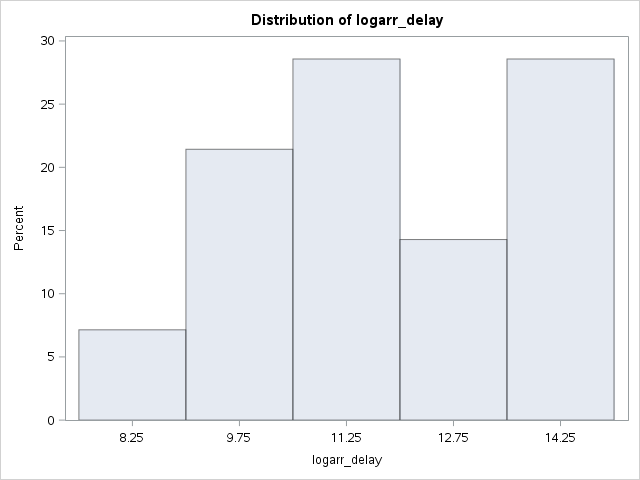

The UNIVARIATE Procedure

IATA_CODE=ORD

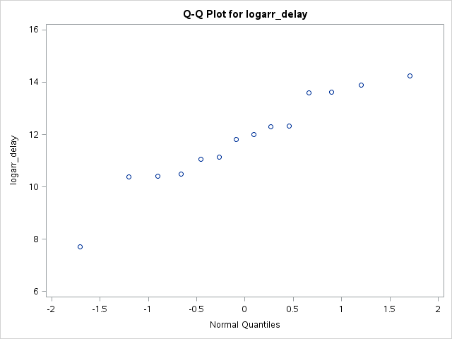

The UNIVARIATE Procedure

Variable: arr_delay (arr_delay)

IATA_CODE=PHL

| Moments |  |  |  |
| --- | --- | --- | --- |
| N | 16 | Sum Weights | 16 |
| Mean | 100615.125 | Sum Observations | 1609842 |
| Std Deviation | 162108.762 | Variance | 2.62793E10 |
| Skewness | 3.06845065 | Kurtosis | 10.5252679 |
| Uncorrected SS | 5.56163E11 | Corrected SS | 3.94189E11 |
| Coeff Variation | 161.117687 | Std Error Mean | 40527.1905 |

| Basic Statistical Measures Location | Basic Statistical Measures Location | Basic Statistical Measures Variability | Basic Statistical Measures Variability |
| --- | --- | --- | --- |
| Mean | 100615.1 | Std Deviation | 162109 |
| Median | 50619.0 | Variance | 2.62793E10 |
| Mode | . | Range | 660102 |
|  |  | Interquartile Range | 102974 |

| Tests for Location: Mu0=0 Test | Tests for Location: Mu0=0 Statistic | Tests for Location: Mu0=0 Statistic | Tests for Location: Mu0=0 p Value | Tests for Location: Mu0=0 p Value |
| --- | --- | --- | --- | --- |
| Student's t | t | 2.482657 | Pr > \|t\| | 0.0254 |
| Sign | M | 8 | Pr >= \|M\| | <.0001 |
| Signed Rank | S | 68 | Pr >= \|S\| | <.0001 |

| Quantiles (Definition 5) Level | Quantiles (Definition 5) Quantile |
| --- | --- |
| 100% Max | 660119.0 |
| 99% | 660119.0 |
| 95% | 660119.0 |
| 90% | 206878.0 |
| 75% Q3 | 112694.5 |
| 50% Median | 50619.0 |
| 25% Q1 | 9720.5 |
| 10% | 641.0 |
| 5% | 17.0 |
| 1% | 17.0 |
| 0% Min | 17.0 |

| Extreme Observations Lowest Value | Extreme Observations Lowest Obs | Extreme Observations Highest Value | Extreme Observations Highest Obs |
| --- | --- | --- | --- |
| 17 | 260 | 112196 | 268 |
| 641 | 267 | 113193 | 261 |
| 6734 | 257 | 185405 | 270 |
| 7548 | 265 | 206878 | 264 |
| 11893 | 262 | 660119 | 256 |

The UNIVARIATE Procedure

Variable: logarr_delay

IATA_CODE=PHL

| Moments |  |  |  |
| --- | --- | --- | --- |
| N | 16 | Sum Weights | 16 |
| Mean | 10.126112 | Sum Observations | 162.017793 |
| Std Deviation | 2.54920538 | Variance | 6.49844806 |
| Skewness | -1.7421107 | Kurtosis | 3.79062819 |
| Uncorrected SS | 1738.08704 | Corrected SS | 97.4767208 |
| Coeff Variation | 25.1745721 | Std Error Mean | 0.63730134 |

| Basic Statistical Measures Location | Basic Statistical Measures Location | Basic Statistical Measures Variability | Basic Statistical Measures Variability |
| --- | --- | --- | --- |
| Mean | 10.12611 | Std Deviation | 2.54921 |
| Median | 10.83114 | Variance | 6.49845 |
| Mode | . | Range | 10.56696 |
|  |  | Interquartile Range | 2.47605 |

| Tests for Location: Mu0=0 Test | Tests for Location: Mu0=0 Statistic | Tests for Location: Mu0=0 Statistic | Tests for Location: Mu0=0 p Value | Tests for Location: Mu0=0 p Value |
| --- | --- | --- | --- | --- |
| Student's t | t | 15.88905 | Pr > \|t\| | <.0001 |
| Sign | M | 8 | Pr >= \|M\| | <.0001 |
| Signed Rank | S | 68 | Pr >= \|S\| | <.0001 |

| Quantiles (Definition 5) Level | Quantiles (Definition 5) Quantile |
| --- | --- |
| 100% Max | 13.40018 |
| 99% | 13.40018 |
| 95% | 13.40018 |
| 90% | 12.23988 |
| 75% Q3 | 11.63243 |
| 50% Median | 10.83114 |
| 25% Q1 | 9.15637 |
| 10% | 6.46303 |
| 5% | 2.83321 |
| 1% | 2.83321 |
| 0% Min | 2.83321 |

| Extreme Observations Lowest Value | Extreme Observations Lowest Obs | Extreme Observations Highest Value | Extreme Observations Highest Obs |
| --- | --- | --- | --- |
| 2.83321 | 260 | 11.6280 | 268 |
| 6.46303 | 267 | 11.6368 | 261 |
| 8.81492 | 257 | 12.1303 | 270 |
| 8.92904 | 265 | 12.2399 | 264 |
| 9.38371 | 262 | 13.4002 | 256 |

The UNIVARIATE Procedure

IATA_CODE=PHL

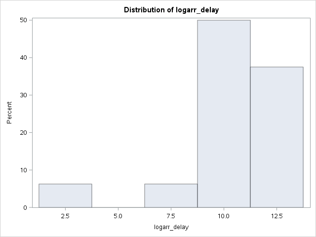

The UNIVARIATE Procedure

IATA_CODE=PHL

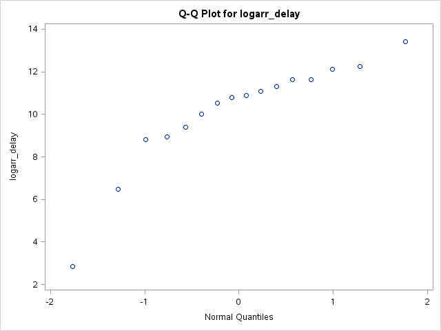

The UNIVARIATE Procedure

Variable: arr_delay (arr_delay)

IATA_CODE=PHX

| Moments |  |  |  |
| --- | --- | --- | --- |
| N | 11 | Sum Weights | 11 |
| Mean | 168159.364 | Sum Observations | 1849753 |
| Std Deviation | 234418.923 | Variance | 5.49522E10 |
| Skewness | 1.55883902 | Kurtosis | 1.04144465 |
| Uncorrected SS | 8.60576E11 | Corrected SS | 5.49522E11 |
| Coeff Variation | 139.402837 | Std Error Mean | 70679.9648 |

| Basic Statistical Measures Location | Basic Statistical Measures Location | Basic Statistical Measures Variability | Basic Statistical Measures Variability |
| --- | --- | --- | --- |
| Mean | 168159.4 | Std Deviation | 234419 |
| Median | 58208.0 | Variance | 5.49522E10 |
| Mode | . | Range | 638303 |
|  |  | Interquartile Range | 254542 |

| Tests for Location: Mu0=0 Test | Tests for Location: Mu0=0 Statistic | Tests for Location: Mu0=0 Statistic | Tests for Location: Mu0=0 p Value | Tests for Location: Mu0=0 p Value |
| --- | --- | --- | --- | --- |
| Student's t | t | 2.379166 | Pr > \|t\| | 0.0387 |
| Sign | M | 5.5 | Pr >= \|M\| | 0.0010 |
| Signed Rank | S | 33 | Pr >= \|S\| | 0.0010 |

| Quantiles (Definition 5) Level | Quantiles (Definition 5) Quantile |
| --- | --- |
| 100% Max | 642465 |
| 99% | 642465 |
| 95% | 642465 |
| 90% | 591764 |
| 75% Q3 | 267376 |
| 50% Median | 58208 |
| 25% Q1 | 12834 |
| 10% | 7339 |
| 5% | 4162 |
| 1% | 4162 |
| 0% Min | 4162 |

| Extreme Observations Lowest Value | Extreme Observations Lowest Obs | Extreme Observations Highest Value | Extreme Observations Highest Obs |
| --- | --- | --- | --- |
| 4162 | 276 | 91237 | 279 |
| 7339 | 277 | 106385 | 278 |
| 12834 | 273 | 267376 | 281 |
| 17215 | 272 | 591764 | 271 |
| 50768 | 275 | 642465 | 280 |

The UNIVARIATE Procedure

Variable: logarr_delay

IATA_CODE=PHX

| Moments |  |  |  |
| --- | --- | --- | --- |
| N | 11 | Sum Weights | 11 |
| Mean | 10.9464796 | Sum Observations | 120.411276 |
| Std Deviation | 1.70480738 | Variance | 2.90636821 |
| Skewness | -0.0031262 | Kurtosis | -1.0874396 |
| Uncorrected SS | 1347.14326 | Corrected SS | 29.0636821 |
| Coeff Variation | 15.5740242 | Std Error Mean | 0.51401877 |

| Basic Statistical Measures Location | Basic Statistical Measures Location | Basic Statistical Measures Variability | Basic Statistical Measures Variability |
| --- | --- | --- | --- |
| Mean | 10.94648 | Std Deviation | 1.70481 |
| Median | 10.97178 | Variance | 2.90637 |
| Mode | . | Range | 5.03932 |
|  |  | Interquartile Range | 3.03656 |

| Tests for Location: Mu0=0 Test | Tests for Location: Mu0=0 Statistic | Tests for Location: Mu0=0 Statistic | Tests for Location: Mu0=0 p Value | Tests for Location: Mu0=0 p Value |
| --- | --- | --- | --- | --- |
| Student's t | t | 21.29588 | Pr > \|t\| | <.0001 |
| Sign | M | 5.5 | Pr >= \|M\| | 0.0010 |
| Signed Rank | S | 33 | Pr >= \|S\| | 0.0010 |

| Quantiles (Definition 5) Level | Quantiles (Definition 5) Quantile |
| --- | --- |
| 100% Max | 13.37307 |
| 99% | 13.37307 |
| 95% | 13.37307 |
| 90% | 13.29086 |
| 75% Q3 | 12.49641 |
| 50% Median | 10.97178 |
| 25% Q1 | 9.45985 |
| 10% | 8.90096 |
| 5% | 8.33375 |
| 1% | 8.33375 |
| 0% Min | 8.33375 |

| Extreme Observations Lowest Value | Extreme Observations Lowest Obs | Extreme Observations Highest Value | Extreme Observations Highest Obs |
| --- | --- | --- | --- |
| 8.33375 | 276 | 11.4212 | 279 |
| 8.90096 | 277 | 11.5748 | 278 |
| 9.45985 | 273 | 12.4964 | 281 |
| 9.75354 | 272 | 13.2909 | 271 |
| 10.83502 | 275 | 13.3731 | 280 |

The UNIVARIATE Procedure

IATA_CODE=PHX

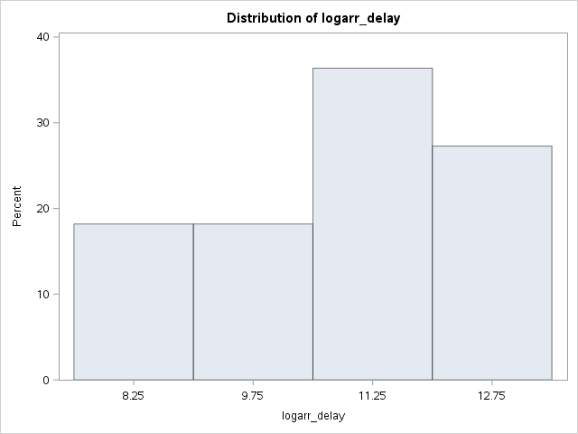

The UNIVARIATE Procedure

IATA_CODE=PHX

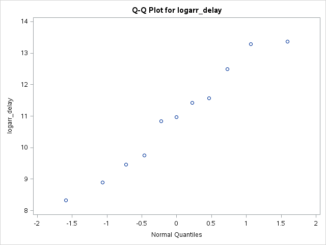

The UNIVARIATE Procedure

Variable: arr_delay (arr_delay)

IATA_CODE=SEA

| Moments |  |  |  |
| --- | --- | --- | --- |
| N | 11 | Sum Weights | 11 |
| Mean | 127283.182 | Sum Observations | 1400115 |
| Std Deviation | 143665.448 | Variance | 2.06398E10 |
| Skewness | 1.82179707 | Kurtosis | 3.96605567 |
| Uncorrected SS | 3.84609E11 | Corrected SS | 2.06398E11 |
| Coeff Variation | 112.870724 | Std Error Mean | 43316.7625 |

| Basic Statistical Measures Location | Basic Statistical Measures Location | Basic Statistical Measures Variability | Basic Statistical Measures Variability |
| --- | --- | --- | --- |
| Mean | 127283.2 | Std Deviation | 143665 |
| Median | 132589.0 | Variance | 2.06398E10 |
| Mode | . | Range | 484232 |
|  |  | Interquartile Range | 132981 |

| Tests for Location: Mu0=0 Test | Tests for Location: Mu0=0 Statistic | Tests for Location: Mu0=0 Statistic | Tests for Location: Mu0=0 p Value | Tests for Location: Mu0=0 p Value |
| --- | --- | --- | --- | --- |
| Student's t | t | 2.938428 | Pr > \|t\| | 0.0148 |
| Sign | M | 5.5 | Pr >= \|M\| | 0.0010 |
| Signed Rank | S | 33 | Pr >= \|S\| | 0.0010 |

| Quantiles (Definition 5) Level | Quantiles (Definition 5) Quantile |
| --- | --- |
| 100% Max | 493786 |
| 99% | 493786 |
| 95% | 493786 |
| 90% | 237909 |
| 75% Q3 | 151031 |
| 50% Median | 132589 |
| 25% Q1 | 18050 |
| 10% | 11181 |
| 5% | 9554 |
| 1% | 9554 |
| 0% Min | 9554 |

| Extreme Observations Lowest Value | Extreme Observations Lowest Obs | Extreme Observations Highest Value | Extreme Observations Highest Obs |
| --- | --- | --- | --- |
| 9554 | 287 | 141900 | 289 |
| 11181 | 291 | 146469 | 290 |
| 18050 | 286 | 151031 | 292 |
| 28196 | 284 | 237909 | 285 |
| 29450 | 288 | 493786 | 283 |

The UNIVARIATE Procedure

Variable: logarr_delay

IATA_CODE=SEA

| Moments |  |  |  |
| --- | --- | --- | --- |
| N | 11 | Sum Weights | 11 |
| Mean | 11.0720154 | Sum Observations | 121.79217 |
| Std Deviation | 1.34250685 | Variance | 1.80232464 |
| Skewness | -0.1334603 | Kurtosis | -1.464266 |
| Uncorrected SS | 1366.50803 | Corrected SS | 18.0232464 |
| Coeff Variation | 12.1252256 | Std Error Mean | 0.40478105 |

| Basic Statistical Measures Location | Basic Statistical Measures Location | Basic Statistical Measures Variability | Basic Statistical Measures Variability |
| --- | --- | --- | --- |
| Mean | 11.07202 | Std Deviation | 1.34251 |
| Median | 11.79501 | Variance | 1.80232 |
| Mode | . | Range | 3.94514 |
|  |  | Interquartile Range | 2.12434 |

| Tests for Location: Mu0=0 Test | Tests for Location: Mu0=0 Statistic | Tests for Location: Mu0=0 Statistic | Tests for Location: Mu0=0 p Value | Tests for Location: Mu0=0 p Value |
| --- | --- | --- | --- | --- |
| Student's t | t | 27.3531 | Pr > \|t\| | <.0001 |
| Sign | M | 5.5 | Pr >= \|M\| | 0.0010 |
| Signed Rank | S | 33 | Pr >= \|S\| | 0.0010 |

| Quantiles (Definition 5) Level | Quantiles (Definition 5) Quantile |
| --- | --- |
| 100% Max | 13.10986 |
| 99% | 13.10986 |
| 95% | 13.10986 |
| 90% | 12.37964 |
| 75% Q3 | 11.92524 |
| 50% Median | 11.79501 |
| 25% Q1 | 9.80090 |
| 10% | 9.32197 |
| 5% | 9.16472 |
| 1% | 9.16472 |
| 0% Min | 9.16472 |

| Extreme Observations Lowest Value | Extreme Observations Lowest Obs | Extreme Observations Highest Value | Extreme Observations Highest Obs |
| --- | --- | --- | --- |
| 9.16472 | 287 | 11.8629 | 289 |
| 9.32197 | 291 | 11.8946 | 290 |
| 9.80090 | 286 | 11.9252 | 292 |
| 10.24694 | 284 | 12.3796 | 285 |
| 10.29045 | 288 | 13.1099 | 283 |

The UNIVARIATE Procedure

IATA_CODE=SEA

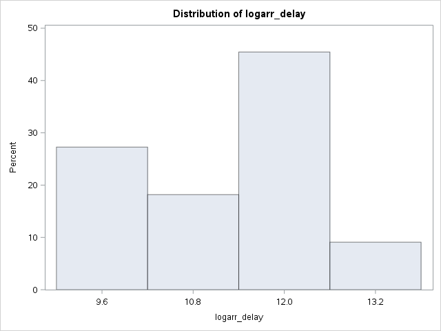

The UNIVARIATE Procedure

IATA_CODE=SEA

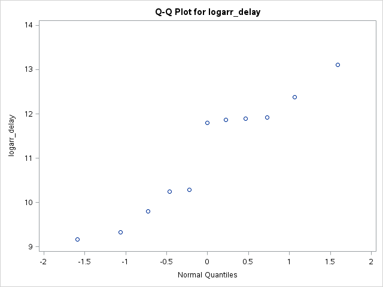

The UNIVARIATE Procedure

Variable: arr_delay (arr_delay)

IATA_CODE=SFO

| Moments |  |  |  |
| --- | --- | --- | --- |
| N | 10 | Sum Weights | 10 |
| Mean | 301002.3 | Sum Observations | 3010023 |
| Std Deviation | 322808.305 | Variance | 1.04205E11 |
| Skewness | 1.35371726 | Kurtosis | 0.76784087 |
| Uncorrected SS | 1.84387E12 | Corrected SS | 9.37847E11 |
| Coeff Variation | 107.244465 | Std Error Mean | 102080.949 |

| Basic Statistical Measures Location | Basic Statistical Measures Location | Basic Statistical Measures Variability | Basic Statistical Measures Variability |
| --- | --- | --- | --- |
| Mean | 301002.3 | Std Deviation | 322808 |
| Median | 204713.0 | Variance | 1.04205E11 |
| Mode | . | Range | 940927 |
|  |  | Interquartile Range | 244492 |

| Tests for Location: Mu0=0 Test | Tests for Location: Mu0=0 Statistic | Tests for Location: Mu0=0 Statistic | Tests for Location: Mu0=0 p Value | Tests for Location: Mu0=0 p Value |
| --- | --- | --- | --- | --- |
| Student's t | t | 2.948663 | Pr > \|t\| | 0.0163 |
| Sign | M | 5 | Pr >= \|M\| | 0.0020 |
| Signed Rank | S | 27.5 | Pr >= \|S\| | 0.0020 |

| Quantiles (Definition 5) Level | Quantiles (Definition 5) Quantile |
| --- | --- |
| 100% Max | 947795.0 |
| 99% | 947795.0 |
| 95% | 947795.0 |
| 90% | 873742.0 |
| 75% Q3 | 324151.0 |
| 50% Median | 204713.0 |
| 25% Q1 | 79659.0 |
| 10% | 18430.5 |
| 5% | 6868.0 |
| 1% | 6868.0 |
| 0% Min | 6868.0 |

| Extreme Observations Lowest Value | Extreme Observations Lowest Obs | Extreme Observations Highest Value | Extreme Observations Highest Obs |
| --- | --- | --- | --- |
| 6868 | 298 | 226138 | 293 |
| 29993 | 297 | 315536 | 302 |
| 79659 | 301 | 324151 | 294 |
| 96906 | 295 | 799689 | 299 |
| 183288 | 296 | 947795 | 300 |

The UNIVARIATE Procedure

Variable: logarr_delay

IATA_CODE=SFO

| Moments |  |  |  |
| --- | --- | --- | --- |
| N | 10 | Sum Weights | 10 |
| Mean | 11.9062934 | Sum Observations | 119.062934 |
| Std Deviation | 1.49983147 | Variance | 2.24949445 |
| Skewness | -0.8726999 | Kurtosis | 0.68043171 |
| Uncorrected SS | 1437.84367 | Corrected SS | 20.24545 |
| Coeff Variation | 12.5969639 | Std Error Mean | 0.47428836 |

| Basic Statistical Measures Location | Basic Statistical Measures Location | Basic Statistical Measures Variability | Basic Statistical Measures Variability |
| --- | --- | --- | --- |
| Mean | 11.90629 | Std Deviation | 1.49983 |
| Median | 12.22386 | Variance | 2.24949 |
| Mode | . | Range | 4.92727 |
|  |  | Interquartile Range | 1.40345 |

| Tests for Location: Mu0=0 Test | Tests for Location: Mu0=0 Statistic | Tests for Location: Mu0=0 Statistic | Tests for Location: Mu0=0 p Value | Tests for Location: Mu0=0 p Value |
| --- | --- | --- | --- | --- |
| Student's t | t | 25.10349 | Pr > \|t\| | <.0001 |
| Sign | M | 5 | Pr >= \|M\| | 0.0020 |
| Signed Rank | S | 27.5 | Pr >= \|S\| | 0.0020 |

| Quantiles (Definition 5) Level | Quantiles (Definition 5) Quantile |
| --- | --- |
| 100% Max | 13.76189 |
| 99% | 13.76189 |
| 95% | 13.76189 |
| 90% | 13.67694 |
| 75% Q3 | 12.68896 |
| 50% Median | 12.22386 |
| 25% Q1 | 11.28551 |
| 10% | 9.57167 |
| 5% | 8.83463 |
| 1% | 8.83463 |
| 0% Min | 8.83463 |

| Extreme Observations Lowest Value | Extreme Observations Lowest Obs | Extreme Observations Highest Value | Extreme Observations Highest Obs |
| --- | --- | --- | --- |
| 8.83463 | 298 | 12.3289 | 293 |
| 10.30872 | 297 | 12.6620 | 302 |
| 11.28551 | 301 | 12.6890 | 294 |
| 11.48150 | 295 | 13.5920 | 299 |
| 12.11881 | 296 | 13.7619 | 300 |

The UNIVARIATE Procedure

IATA_CODE=SFO

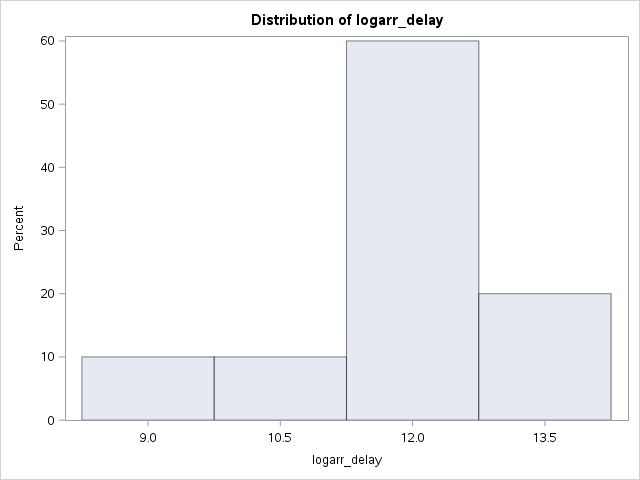

The UNIVARIATE Procedure

IATA_CODE=SFO

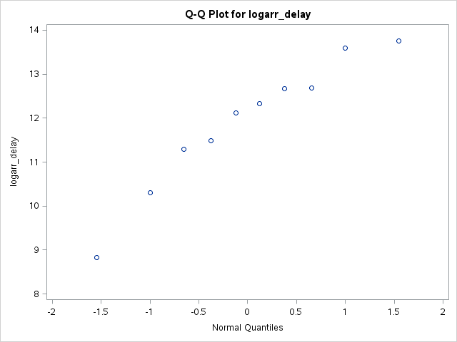

The UNIVARIATE Procedure

Variable: arr_delay (arr_delay)

IATA_CODE=SLC

| Moments |  |  |  |
| --- | --- | --- | --- |
| N | 11 | Sum Weights | 11 |
| Mean | 89822.7273 | Sum Observations | 988050 |
| Std Deviation | 134887.876 | Variance | 1.81947E10 |
| Skewness | 1.86866176 | Kurtosis | 2.5556798 |
| Uncorrected SS | 2.70697E11 | Corrected SS | 1.81947E11 |
| Coeff Variation | 150.17121 | Std Error Mean | 40670.2249 |

| Basic Statistical Measures Location | Basic Statistical Measures Location | Basic Statistical Measures Variability | Basic Statistical Measures Variability |
| --- | --- | --- | --- |
| Mean | 89822.73 | Std Deviation | 134888 |
| Median | 33322.00 | Variance | 1.81947E10 |
| Mode | . | Range | 407063 |
|  |  | Interquartile Range | 98080 |

| Tests for Location: Mu0=0 Test | Tests for Location: Mu0=0 Statistic | Tests for Location: Mu0=0 Statistic | Tests for Location: Mu0=0 p Value | Tests for Location: Mu0=0 p Value |
| --- | --- | --- | --- | --- |
| Student's t | t | 2.208562 | Pr > \|t\| | 0.0517 |
| Sign | M | 5.5 | Pr >= \|M\| | 0.0010 |
| Signed Rank | S | 33 | Pr >= \|S\| | 0.0010 |

| Quantiles (Definition 5) Level | Quantiles (Definition 5) Quantile |
| --- | --- |
| 100% Max | 407122 |
| 99% | 407122 |
| 95% | 407122 |
| 90% | 294672 |
| 75% Q3 | 103114 |
| 50% Median | 33322 |
| 25% Q1 | 5034 |
| 10% | 4052 |
| 5% | 59 |
| 1% | 59 |
| 0% Min | 59 |

| Extreme Observations Lowest Value | Extreme Observations Lowest Obs | Extreme Observations Highest Value | Extreme Observations Highest Obs |
| --- | --- | --- | --- |
| 59 | 307 | 40385 | 305 |
| 4052 | 313 | 61685 | 303 |
| 5034 | 312 | 103114 | 311 |
| 10612 | 304 | 294672 | 306 |
| 27993 | 310 | 407122 | 309 |

The UNIVARIATE Procedure

Variable: logarr_delay

IATA_CODE=SLC

| Moments |  |  |  |
| --- | --- | --- | --- |
| N | 11 | Sum Weights | 11 |
| Mean | 9.95654397 | Sum Observations | 109.521984 |
| Std Deviation | 2.44760196 | Variance | 5.99075533 |
| Skewness | -1.3423322 | Kurtosis | 2.6758229 |
| Uncorrected SS | 1150.368 | Corrected SS | 59.9075533 |
| Coeff Variation | 24.5828469 | Std Error Mean | 0.73797976 |

| Basic Statistical Measures Location | Basic Statistical Measures Location | Basic Statistical Measures Variability | Basic Statistical Measures Variability |
| --- | --- | --- | --- |
| Mean | 9.95654 | Std Deviation | 2.44760 |
| Median | 10.41397 | Variance | 5.99076 |
| Mode | . | Range | 8.83933 |
|  |  | Interquartile Range | 3.01962 |

| Tests for Location: Mu0=0 Test | Tests for Location: Mu0=0 Statistic | Tests for Location: Mu0=0 Statistic | Tests for Location: Mu0=0 p Value | Tests for Location: Mu0=0 p Value |
| --- | --- | --- | --- | --- |
| Student's t | t | 13.49162 | Pr > \|t\| | <.0001 |
| Sign | M | 5.5 | Pr >= \|M\| | 0.0010 |
| Signed Rank | S | 33 | Pr >= \|S\| | 0.0010 |

| Quantiles (Definition 5) Level | Quantiles (Definition 5) Quantile |
| --- | --- |
| 100% Max | 12.91687 |
| 99% | 12.91687 |
| 95% | 12.91687 |
| 90% | 12.59362 |
| 75% Q3 | 11.54359 |
| 50% Median | 10.41397 |
| 25% Q1 | 8.52397 |
| 10% | 8.30697 |
| 5% | 4.07754 |
| 1% | 4.07754 |
| 0% Min | 4.07754 |

| Extreme Observations Lowest Value | Extreme Observations Lowest Obs | Extreme Observations Highest Value | Extreme Observations Highest Obs |
| --- | --- | --- | --- |
| 4.07754 | 307 | 10.6062 | 305 |
| 8.30697 | 313 | 11.0298 | 303 |
| 8.52397 | 312 | 11.5436 | 311 |
| 9.26974 | 304 | 12.5936 | 306 |
| 10.23971 | 310 | 12.9169 | 309 |

The UNIVARIATE Procedure

IATA_CODE=SLC

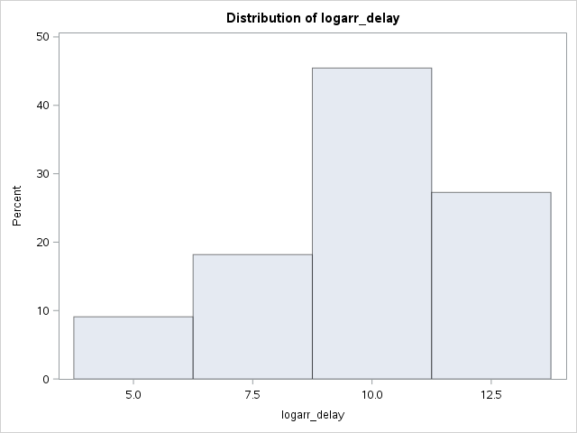

The UNIVARIATE Procedure

IATA_CODE=SLC

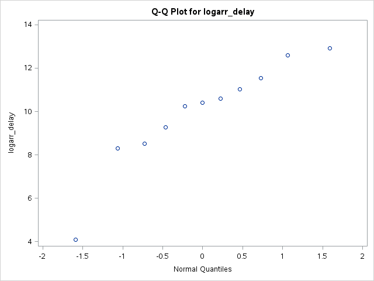

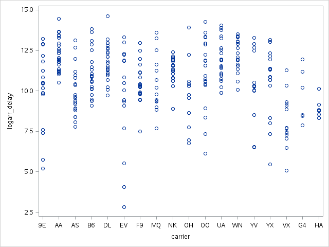

Summary of Arrival Delays

The MEANS Procedure

| Analysis Variable : logarr_delay IATA_CODE | Analysis Variable : logarr_delay carrier | Analysis Variable : logarr_delay N Obs | Analysis Variable : logarr_delay N | Analysis Variable : logarr_delay Mean | Analysis Variable : logarr_delay Maximum | Analysis Variable : logarr_delay Minimum | Analysis Variable : logarr_delay Range | Analysis Variable : logarr_delay Std Dev |
| --- | --- | --- | --- | --- | --- | --- | --- | --- |
| ATL | 9E | 1 | 1 | 12.8768 | 12.8768 | 12.8768 | 0 | . |
|  | AA | 1 | 1 | 11.9065 | 11.9065 | 11.9065 | 0 | . |
|  | AS | 1 | 1 | 7.7732 | 7.7732 | 7.7732 | 0 | . |
|  | B6 | 1 | 1 | 10.8984 | 10.8984 | 10.8984 | 0 | . |
|  | DL | 1 | 1 | 14.6218 | 14.6218 | 14.6218 | 0 | . |
|  | EV | 1 | 1 | 11.8545 | 11.8545 | 11.8545 | 0 | . |
|  | F9 | 1 | 1 | 11.1122 | 11.1122 | 11.1122 | 0 | . |
|  | MQ | 1 | 1 | 8.9837 | 8.9837 | 8.9837 | 0 | . |
|  | NK | 1 | 1 | 11.5327 | 11.5327 | 11.5327 | 0 | . |
|  | OH | 1 | 1 | 9.7690 | 9.7690 | 9.7690 | 0 | . |
|  | OO | 1 | 1 | 12.9437 | 12.9437 | 12.9437 | 0 | . |
|  | UA | 1 | 1 | 10.9692 | 10.9692 | 10.9692 | 0 | . |
|  | WN | 1 | 1 | 12.8970 | 12.8970 | 12.8970 | 0 | . |
|  | YV | 1 | 1 | 10.5079 | 10.5079 | 10.5079 | 0 | . |
|  | YX | 1 | 1 | 10.6654 | 10.6654 | 10.6654 | 0 | . |
| BOS | 9E | 1 | 1 | 11.2616 | 11.2616 | 11.2616 | 0 | . |
|  | AA | 1 | 1 | 12.8052 | 12.8052 | 12.8052 | 0 | . |
|  | AS | 1 | 1 | 10.4066 | 10.4066 | 10.4066 | 0 | . |
|  | B6 | 1 | 1 | 13.8107 | 13.8107 | 13.8107 | 0 | . |
|  | DL | 1 | 1 | 12.3330 | 12.3330 | 12.3330 | 0 | . |
|  | EV | 1 | 1 | 10.0451 | 10.0451 | 10.0451 | 0 | . |
|  | MQ | 1 | 1 | 10.1829 | 10.1829 | 10.1829 | 0 | . |
|  | NK | 1 | 1 | 11.3232 | 11.3232 | 11.3232 | 0 | . |
|  | OO | 1 | 1 | 10.9448 | 10.9448 | 10.9448 | 0 | . |
|  | UA | 1 | 1 | 12.3252 | 12.3252 | 12.3252 | 0 | . |
|  | VX | 1 | 1 | 7.4012 | 7.4012 | 7.4012 | 0 | . |
|  | WN | 1 | 1 | 11.9519 | 11.9519 | 11.9519 | 0 | . |
|  | YV | 1 | 1 | 6.5338 | 6.5338 | 6.5338 | 0 | . |
|  | YX | 1 | 1 | 11.3663 | 11.3663 | 11.3663 | 0 | . |
| BWI | 9E | 1 | 1 | 10.4595 | 10.4595 | 10.4595 | 0 | . |

[output cut: 283 more lines]

Summary of Arrival Delays

The Mixed Procedure

| Model Information |  |
| --- | --- |
| Data Set | WORK.DELAY_2_WAY |
| Dependent Variable | logarr_delay |
| Covariance Structure | Diagonal |
| Estimation Method | REML |
| Residual Variance Method | Profile |
| Fixed Effects SE Method | Model-Based |
| Degrees of Freedom Method | Residual |

| Class Level Information Class | Class Level Information Levels | Class Level Information Values |
| --- | --- | --- |
| IATA_CODE | 25 | ATL BOS BWI CLT DEN DFW DTW EWR FLL IAD IAH JFK LAS LAX LGA MCO MDW MIA MSP ORD PHL PHX SEA SFO SLC |
| carrier | 18 | 9E AA AS B6 DL EV F9 G4 HA MQ NK OH OO UA VX WN YV YX |

| Dimensions |  |
| --- | --- |
| Covariance Parameters | 1 |
| Columns in X | 44 |
| Columns in Z | 0 |
| Subjects | 1 |
| Max Obs per Subject | 313 |

| Number of Observations |  |
| --- | --- |
| Number of Observations Read | 313 |
| Number of Observations Used | 313 |
| Number of Observations Not Used | 0 |

| Covariance Parameter Estimates Cov Parm | Covariance Parameter Estimates Estimate |
| --- | --- |
| Residual | 2.5348 |

| Fit Statistics |  |
| --- | --- |
| -2 Res Log Likelihood | 1127.5 |
| AIC (Smaller is Better) | 1129.5 |
| AICC (Smaller is Better) | 1129.5 |
| BIC (Smaller is Better) | 1133.1 |

| Type 3 Tests of Fixed Effects Effect | Type 3 Tests of Fixed Effects Num DF | Type 3 Tests of Fixed Effects Den DF | Type 3 Tests of Fixed Effects F Value | Type 3 Tests of Fixed Effects Pr > F |
| --- | --- | --- | --- | --- |
| IATA_CODE | 24 | 271 | 2.36 | 0.0005 |
| carrier | 17 | 271 | 8.40 | <.0001 |

| Least Squares Means Effect | Least Squares Means IATA_CODE | Least Squares Means carrier | Least Squares Means Estimate | Least Squares Means Standard Error | Least Squares Means DF | Least Squares Means t Value | Least Squares Means Pr > \|t\| | Least Squares Means Alpha | Least Squares Means Lower | Least Squares Means Upper |
| --- | --- | --- | --- | --- | --- | --- | --- | --- | --- | --- |
| IATA_CODE | ATL |  | 10.9267 | 0.4157 | 271 | 26.28 | <.0001 | 0.05 | 10.1082 | 11.7451 |
| IATA_CODE | BOS |  | 10.6284 | 0.4307 | 271 | 24.68 | <.0001 | 0.05 | 9.7805 | 11.4764 |
| IATA_CODE | BWI |  | 9.5008 | 0.4144 | 271 | 22.93 | <.0001 | 0.05 | 8.6849 | 10.3167 |
| IATA_CODE | CLT |  | 10.6035 | 0.4477 | 271 | 23.68 | <.0001 | 0.05 | 9.7221 | 11.4850 |
| IATA_CODE | DEN |  | 10.2830 | 0.4469 | 271 | 23.01 | <.0001 | 0.05 | 9.4031 | 11.1629 |
| IATA_CODE | DFW |  | 11.0509 | 0.4478 | 271 | 24.68 | <.0001 | 0.05 | 10.1693 | 11.9325 |
| IATA_CODE | DTW |  | 10.4082 | 0.4157 | 271 | 25.04 | <.0001 | 0.05 | 9.5898 | 11.2267 |
| IATA_CODE | EWR |  | 10.8695 | 0.4144 | 271 | 26.23 | <.0001 | 0.05 | 10.0536 | 11.6854 |
| IATA_CODE | FLL |  | 9.8536 | 0.4659 | 271 | 21.15 | <.0001 | 0.05 | 8.9364 | 10.7709 |
| IATA_CODE | IAD |  | 9.8810 | 0.4306 | 271 | 22.95 | <.0001 | 0.05 | 9.0333 | 10.7287 |
| IATA_CODE | IAH |  | 10.7466 | 0.4666 | 271 | 23.03 | <.0001 | 0.05 | 9.8280 | 11.6653 |
| IATA_CODE | JFK |  | 11.2252 | 0.4868 | 271 | 23.06 | <.0001 | 0.05 | 10.2668 | 12.1835 |
| IATA_CODE | LAS |  | 11.0683 | 0.4657 | 271 | 23.76 | <.0001 | 0.05 | 10.1513 | 11.9852 |
| IATA_CODE | LAX |  | 11.4383 | 0.4657 | 271 | 24.56 | <.0001 | 0.05 | 10.5214 | 12.3553 |
| IATA_CODE | LGA |  | 11.4267 | 0.4308 | 271 | 26.52 | <.0001 | 0.05 | 10.5785 | 12.2750 |
| IATA_CODE | MCO |  | 9.5340 | 0.4476 | 271 | 21.30 | <.0001 | 0.05 | 8.6527 | 10.4153 |
| IATA_CODE | MDW |  | 9.5617 | 0.8135 | 271 | 11.75 | <.0001 | 0.05 | 7.9600 | 11.1633 |
| IATA_CODE | MIA |  | 9.6170 | 0.5741 | 271 | 16.75 | <.0001 | 0.05 | 8.4867 | 10.7472 |
| IATA_CODE | MSP |  | 10.0112 | 0.4157 | 271 | 24.08 | <.0001 | 0.05 | 9.1927 | 10.8296 |
| IATA_CODE | ORD |  | 11.6972 | 0.4306 | 271 | 27.17 | <.0001 | 0.05 | 10.8495 | 12.5448 |
| IATA_CODE | PHL |  | 9.9406 | 0.4017 | 271 | 24.74 | <.0001 | 0.05 | 9.1496 | 10.7315 |
| IATA_CODE | PHX |  | 10.4729 | 0.4874 | 271 | 21.49 | <.0001 | 0.05 | 9.5134 | 11.4324 |
| IATA_CODE | SEA |  | 10.8151 | 0.4876 | 271 | 22.18 | <.0001 | 0.05 | 9.8552 | 11.7750 |
| IATA_CODE | SFO |  | 11.6928 | 0.5121 | 271 | 22.83 | <.0001 | 0.05 | 10.6845 | 12.7010 |
| IATA_CODE | SLC |  | 9.4061 | 0.4878 | 271 | 19.28 | <.0001 | 0.05 | 8.4457 | 10.3664 |
| carrier |  | 9E | 10.2025 | 0.3812 | 271 | 26.76 | <.0001 | 0.05 | 9.4520 | 10.9530 |
| carrier |  | AA | 12.2472 | 0.3266 | 271 | 37.50 | <.0001 | 0.05 | 11.6041 | 12.8902 |
| carrier |  | AS | 9.8398 | 0.3510 | 271 | 28.04 | <.0001 | 0.05 | 9.1488 | 10.5308 |
| carrier |  | B6 | 11.0395 | 0.3424 | 271 | 32.24 | <.0001 | 0.05 | 10.3653 | 11.7137 |
| carrier |  | DL | 11.7976 | 0.3184 | 271 | 37.05 | <.0001 | 0.05 | 11.1707 | 12.4245 |
| carrier |  | EV | 9.7368 | 0.4051 | 271 | 24.03 | <.0001 | 0.05 | 8.9391 | 10.5344 |
| carrier |  | F9 | 10.4568 | 0.3598 | 271 | 29.06 | <.0001 | 0.05 | 9.7484 | 11.1651 |
| carrier |  | G4 | 9.6952 | 0.6715 | 271 | 14.44 | <.0001 | 0.05 | 8.3733 | 11.0171 |
| carrier |  | HA | 8.3489 | 0.6747 | 271 | 12.37 | <.0001 | 0.05 | 7.0206 | 9.6772 |
| carrier |  | MQ | 10.3515 | 0.4348 | 271 | 23.81 | <.0001 | 0.05 | 9.4954 | 11.2075 |
| carrier |  | NK | 11.1970 | 0.3809 | 271 | 29.40 | <.0001 | 0.05 | 10.4472 | 11.9468 |
| carrier |  | OH | 9.6311 | 0.4919 | 271 | 19.58 | <.0001 | 0.05 | 8.6627 | 10.5996 |
| carrier |  | OO | 11.2358 | 0.3258 | 271 | 34.48 | <.0001 | 0.05 | 10.5943 | 11.8773 |
| carrier |  | UA | 11.8333 | 0.3342 | 271 | 35.41 | <.0001 | 0.05 | 11.1754 | 12.4913 |
| carrier |  | VX | 8.0633 | 0.4346 | 271 | 18.55 | <.0001 | 0.05 | 7.2077 | 8.9188 |
| carrier |  | WN | 12.3370 | 0.3593 | 271 | 34.33 | <.0001 | 0.05 | 11.6296 | 13.0444 |
| carrier |  | YV | 10.4465 | 0.4518 | 271 | 23.12 | <.0001 | 0.05 | 9.5570 | 11.3360 |
| carrier |  | YX | 10.6549 | 0.3812 | 271 | 27.95 | <.0001 | 0.05 | 9.9044 | 11.4055 |

| Differences of Least Squares Means Effect | Differences of Least Squares Means IATA_CODE | Differences of Least Squares Means carrier | Differences of Least Squares Means IATA_CODE | Differences of Least Squares Means carrier | Differences of Least Squares Means Estimate | Differences of Least Squares Means Standard Error | Differences of Least Squares Means DF | Differences of Least Squares Means t Value | Differences of Least Squares Means Pr > \|t\| | Differences of Least Squares Means Adjustment | Differences of Least Squares Means Adj P | Differences of Least Squares Means Alpha | Differences of Least Squares Means Lower | Differences of Least Squares Means Upper | Differences of Least Squares Means Adj Lower | Differences of Least Squares Means Adj Upper |
| --- | --- | --- | --- | --- | --- | --- | --- | --- | --- | --- | --- | --- | --- | --- | --- | --- |
| IATA_CODE | ATL |  | BOS |  | 0.2982 | 0.5939 | 271 | 0.50 | 0.6159 | Bonferroni | 1.0000 | 0.05 | -0.8709 | 1.4674 | -1.9693 | 2.5657 |
| IATA_CODE | ATL |  | BWI |  | 1.4259 | 0.5852 | 271 | 2.44 | 0.0155 | Bonferroni | 1.0000 | 0.05 | 0.2736 | 2.5781 | -0.8087 | 3.6604 |
| IATA_CODE | ATL |  | CLT |  | 0.3231 | 0.6045 | 271 | 0.53 | 0.5934 | Bonferroni | 1.0000 | 0.05 | -0.8669 | 1.5132 | -1.9848 | 2.6311 |
| IATA_CODE | ATL |  | DEN |  | 0.6437 | 0.6099 | 271 | 1.06 | 0.2922 | Bonferroni | 1.0000 | 0.05 | -0.5572 | 1.8445 | -1.6852 | 2.9725 |
| IATA_CODE | ATL |  | DFW |  | -0.1242 | 0.6048 | 271 | -0.21 | 0.8374 | Bonferroni | 1.0000 | 0.05 | -1.3150 | 1.0665 | -2.4335 | 2.1850 |
| IATA_CODE | ATL |  | DTW |  | 0.5184 | 0.5814 | 271 | 0.89 | 0.3733 | Bonferroni | 1.0000 | 0.05 | -0.6261 | 1.6630 | -1.7013 | 2.7382 |
| IATA_CODE | ATL |  | EWR |  | 0.05718 | 0.5852 | 271 | 0.10 | 0.9222 | Bonferroni | 1.0000 | 0.05 | -1.0950 | 1.2094 | -2.1774 | 2.2918 |
| IATA_CODE | ATL |  | FLL |  | 1.0730 | 0.6245 | 271 | 1.72 | 0.0869 | Bonferroni | 1.0000 | 0.05 | -0.1565 | 2.3026 | -1.3115 | 3.4576 |
| IATA_CODE | ATL |  | IAD |  | 1.0457 | 0.5937 | 271 | 1.76 | 0.0793 | Bonferroni | 1.0000 | 0.05 | -0.1233 | 2.2146 | -1.2213 | 3.3127 |
| IATA_CODE | ATL |  | IAH |  | 0.1800 | 0.6188 | 271 | 0.29 | 0.7713 | Bonferroni | 1.0000 | 0.05 | -1.0381 | 1.3982 | -2.1825 | 2.5426 |
| IATA_CODE | ATL |  | JFK |  | -0.2985 | 0.6401 | 271 | -0.47 | 0.6414 | Bonferroni | 1.0000 | 0.05 | -1.5587 | 0.9617 | -2.7425 | 2.1455 |
| IATA_CODE | ATL |  | LAS |  | -0.1416 | 0.6282 | 271 | -0.23 | 0.8218 | Bonferroni | 1.0000 | 0.05 | -1.3784 | 1.0952 | -2.5402 | 2.2570 |
| IATA_CODE | ATL |  | LAX |  | -0.5117 | 0.6282 | 271 | -0.81 | 0.4161 | Bonferroni | 1.0000 | 0.05 | -1.7484 | 0.7251 | -2.9103 | 1.8869 |
| IATA_CODE | ATL |  | LGA |  | -0.5001 | 0.5921 | 271 | -0.84 | 0.3991 | Bonferroni | 1.0000 | 0.05 | -1.6659 | 0.6657 | -2.7610 | 1.7609 |
| IATA_CODE | ATL |  | MCO |  | 1.3927 | 0.6068 | 271 | 2.30 | 0.0225 | Bonferroni | 1.0000 | 0.05 | 0.1980 | 2.5874 | -0.9242 | 3.7096 |
| IATA_CODE | ATL |  | MDW |  | 1.3650 | 0.9097 | 271 | 1.50 | 0.1346 | Bonferroni | 1.0000 | 0.05 | -0.4260 | 3.1560 | -2.1084 | 4.8385 |
| IATA_CODE | ATL |  | MIA |  | 1.3097 | 0.7031 | 271 | 1.86 | 0.0636 | Bonferroni | 1.0000 | 0.05 | -0.07459 | 2.6940 | -1.3750 | 3.9944 |
| IATA_CODE | ATL |  | MSP |  | 0.9155 | 0.5814 | 271 | 1.57 | 0.1165 | Bonferroni | 1.0000 | 0.05 | -0.2291 | 2.0600 | -1.3042 | 3.1352 |
| IATA_CODE | ATL |  | ORD |  | -0.7705 | 0.5938 | 271 | -1.30 | 0.1955 | Bonferroni | 1.0000 | 0.05 | -1.9395 | 0.3985 | -3.0376 | 1.4966 |
| IATA_CODE | ATL |  | PHL |  | 0.9861 | 0.5729 | 271 | 1.72 | 0.0863 | Bonferroni | 1.0000 | 0.05 | -0.1418 | 2.1140 | -1.2013 | 3.1735 |
| IATA_CODE | ATL |  | PHX |  | 0.4538 | 0.6392 | 271 | 0.71 | 0.4784 | Bonferroni | 1.0000 | 0.05 | -0.8047 | 1.7123 | -1.9870 | 2.8945 |
| IATA_CODE | ATL |  | SEA |  | 0.1116 | 0.6415 | 271 | 0.17 | 0.8621 | Bonferroni | 1.0000 | 0.05 | -1.1514 | 1.3745 | -2.3378 | 2.5610 |
| IATA_CODE | ATL |  | SFO |  | -0.7661 | 0.6609 | 271 | -1.16 | 0.2474 | Bonferroni | 1.0000 | 0.05 | -2.0673 | 0.5351 | -3.2897 | 1.7575 |
| IATA_CODE | ATL |  | SLC |  | 1.5206 | 0.6352 | 271 | 2.39 | 0.0174 | Bonferroni | 1.0000 | 0.05 | 0.2700 | 2.7712 | -0.9049 | 3.9461 |
| IATA_CODE | BOS |  | BWI |  | 1.1276 | 0.5952 | 271 | 1.89 | 0.0592 | Bonferroni | 1.0000 | 0.05 | -0.04415 | 2.2994 | -1.1449 | 3.4001 |
| IATA_CODE | BOS |  | CLT |  | 0.02490 | 0.6170 | 271 | 0.04 | 0.9678 | Bonferroni | 1.0000 | 0.05 | -1.1898 | 1.2396 | -2.3309 | 2.3807 |
| IATA_CODE | BOS |  | DEN |  | 0.3454 | 0.6186 | 271 | 0.56 | 0.5770 | Bonferroni | 1.0000 | 0.05 | -0.8724 | 1.5633 | -2.0165 | 2.7073 |
| IATA_CODE | BOS |  | DFW |  | -0.4225 | 0.6152 | 271 | -0.69 | 0.4928 | Bonferroni | 1.0000 | 0.05 | -1.6337 | 0.7888 | -2.7716 | 1.9266 |
| IATA_CODE | BOS |  | DTW |  | 0.2202 | 0.5939 | 271 | 0.37 | 0.7111 | Bonferroni | 1.0000 | 0.05 | -0.9490 | 1.3894 | -2.0473 | 2.4877 |
| IATA_CODE | BOS |  | EWR |  | -0.2411 | 0.5952 | 271 | -0.41 | 0.6858 | Bonferroni | 1.0000 | 0.05 | -1.4128 | 0.9307 | -2.5136 | 2.0314 |

[output cut: 423 more lines]

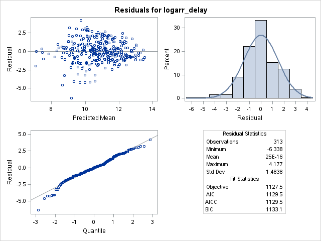

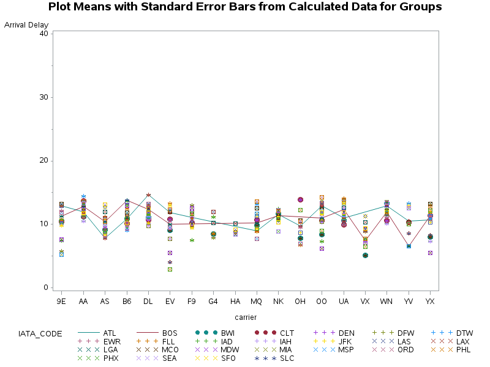

Plot Means with Standard Error Bars from Calculated Data for Groups

The GLM Procedure

| Class Level Information Class | Class Level Information Levels | Class Level Information Values |
| --- | --- | --- |
| IATA_CODE | 25 | ATL BOS BWI CLT DEN DFW DTW EWR FLL IAD IAH JFK LAS LAX LGA MCO MDW MIA MSP ORD PHL PHX SEA SFO SLC |
| carrier | 18 | 9E AA AS B6 DL EV F9 G4 HA MQ NK OH OO UA VX WN YV YX |

| Number of Observations Read | 313 |
| --- | --- |
| Number of Observations Used | 313 |

Plot Means with Standard Error Bars from Calculated Data for Groups

The GLM Procedure

Dependent Variable: logarr_delay

| Source | DF | Sum of Squares | Mean Square | F Value | Pr > F |
| --- | --- | --- | --- | --- | --- |
| Model | 41 | 493.069594 | 12.026088 | 4.74 | <.0001 |
| Error | 271 | 686.939030 | 2.534830 |  |  |
| Corrected Total | 312 | 1180.008623 |  |  |  |

| R-Square | Coeff Var | Root MSE | logarr_delay Mean |
| --- | --- | --- | --- |
| 0.417853 | 14.72845 | 1.592115 | 10.80979 |

| Source | DF | Type I SS | Mean Square | F Value | Pr > F |
| --- | --- | --- | --- | --- | --- |
| carrier | 17 | 349.6810900 | 20.5694759 | 8.11 | <.0001 |
| IATA_CODE | 24 | 143.3885038 | 5.9745210 | 2.36 | 0.0005 |

| Source | DF | Type III SS | Mean Square | F Value | Pr > F |
| --- | --- | --- | --- | --- | --- |
| carrier | 17 | 362.1683262 | 21.3040192 | 8.40 | <.0001 |
| IATA_CODE | 24 | 143.3885038 | 5.9745210 | 2.36 | 0.0005 |

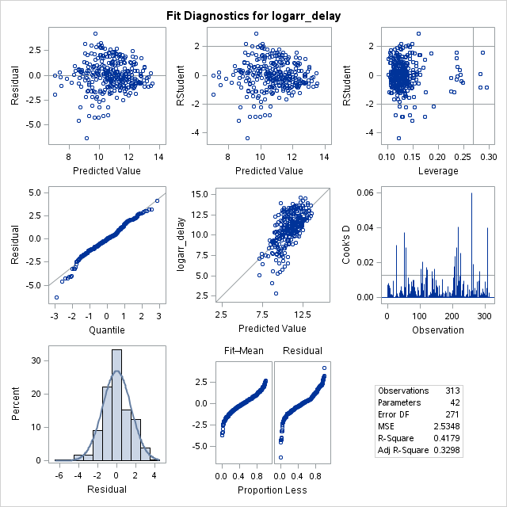

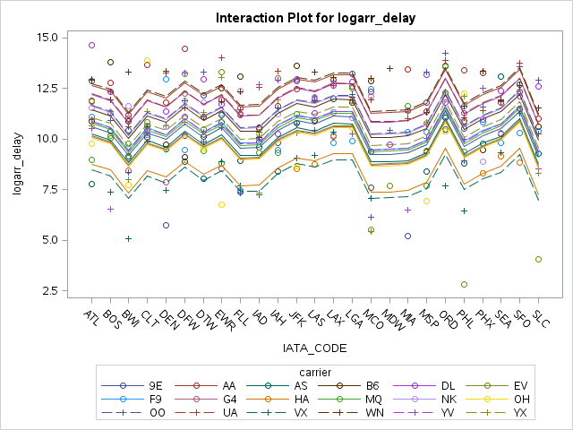

Plot Means with Standard Error Bars from Calculated Data for Groups

The GLM Procedure

Least Squares Means

Adjustment for Multiple Comparisons: Bonferroni

| carrier | logarr_delay LSMEAN | LSMEAN Number |
| --- | --- | --- |
| 9E | 10.2024997 | 1 |
| AA | 12.2471900 | 2 |
| AS | 9.8397954 | 3 |
| B6 | 11.0395355 | 4 |
| DL | 11.7975682 | 5 |
| EV | 9.7367545 | 6 |
| F9 | 10.4567752 | 7 |
| G4 | 9.6952036 | 8 |
| HA | 8.3488774 | 9 |
| MQ | 10.3514515 | 10 |
| NK | 11.1969849 | 11 |
| OH | 9.6311487 | 12 |
| OO | 11.2357992 | 13 |
| UA | 11.8333159 | 14 |
| VX | 8.0632766 | 15 |
| WN | 12.3369753 | 16 |
| YV | 10.4465193 | 17 |
| YX | 10.6549475 | 18 |

| Least Squares Means for Effect carrier t for H0: LSMean(i)=LSMean(j) / Pr > \|t\| Dependent Variable: logarr_delay i/j | Least Squares Means for Effect carrier t for H0: LSMean(i)=LSMean(j) / Pr > \|t\| Dependent Variable: logarr_delay 1 | Least Squares Means for Effect carrier t for H0: LSMean(i)=LSMean(j) / Pr > \|t\| Dependent Variable: logarr_delay 2 | Least Squares Means for Effect carrier t for H0: LSMean(i)=LSMean(j) / Pr > \|t\| Dependent Variable: logarr_delay 3 | Least Squares Means for Effect carrier t for H0: LSMean(i)=LSMean(j) / Pr > \|t\| Dependent Variable: logarr_delay 4 | Least Squares Means for Effect carrier t for H0: LSMean(i)=LSMean(j) / Pr > \|t\| Dependent Variable: logarr_delay 5 | Least Squares Means for Effect carrier t for H0: LSMean(i)=LSMean(j) / Pr > \|t\| Dependent Variable: logarr_delay 6 | Least Squares Means for Effect carrier t for H0: LSMean(i)=LSMean(j) / Pr > \|t\| Dependent Variable: logarr_delay 7 | Least Squares Means for Effect carrier t for H0: LSMean(i)=LSMean(j) / Pr > \|t\| Dependent Variable: logarr_delay 8 | Least Squares Means for Effect carrier t for H0: LSMean(i)=LSMean(j) / Pr > \|t\| Dependent Variable: logarr_delay 9 | Least Squares Means for Effect carrier t for H0: LSMean(i)=LSMean(j) / Pr > \|t\| Dependent Variable: logarr_delay 10 | Least Squares Means for Effect carrier t for H0: LSMean(i)=LSMean(j) / Pr > \|t\| Dependent Variable: logarr_delay 11 | Least Squares Means for Effect carrier t for H0: LSMean(i)=LSMean(j) / Pr > \|t\| Dependent Variable: logarr_delay 12 | Least Squares Means for Effect carrier t for H0: LSMean(i)=LSMean(j) / Pr > \|t\| Dependent Variable: logarr_delay 13 | Least Squares Means for Effect carrier t for H0: LSMean(i)=LSMean(j) / Pr > \|t\| Dependent Variable: logarr_delay 14 | Least Squares Means for Effect carrier t for H0: LSMean(i)=LSMean(j) / Pr > \|t\| Dependent Variable: logarr_delay 15 | Least Squares Means for Effect carrier t for H0: LSMean(i)=LSMean(j) / Pr > \|t\| Dependent Variable: logarr_delay 16 | Least Squares Means for Effect carrier t for H0: LSMean(i)=LSMean(j) / Pr > \|t\| Dependent Variable: logarr_delay 17 | Least Squares Means for Effect carrier t for H0: LSMean(i)=LSMean(j) / Pr > \|t\| Dependent Variable: logarr_delay 18 |
| --- | --- | --- | --- | --- | --- | --- | --- | --- | --- | --- | --- | --- | --- | --- | --- | --- | --- | --- |
| 1 |  | -4.09033 0.0087 | 0.701092 1.0000 | -1.6372 1.0000 | -3.21139 0.2265 | 0.841932 1.0000 | -0.48582 1.0000 | 0.656728 1.0000 | 2.364315 1.0000 | -0.26123 1.0000 | -1.85389 1.0000 | 0.928525 1.0000 | -2.05812 1.0000 | -3.22819 0.2141 | 3.703778 0.0394 | -4.05537 0.0100 | -0.41591 1.0000 | -0.85043 1.0000 |
| 2 | 4.090329 0.0087 |  | 5.044568 0.0001 | 2.563917 1.0000 | 0.985676 1.0000 | 4.812303 0.0004 | 3.701197 0.0398 | 3.424368 0.1089 | 5.211212 <.0001 | 3.49845 0.0837 | 2.101895 1.0000 | 4.443242 0.0020 | 2.19163 1.0000 | 0.889986 1.0000 | 7.724276 <.0001 | -0.18467 1.0000 | 3.240782 0.2052 | 3.184868 0.2475 |
| 3 | -0.70109 1.0000 | -5.04457 0.0001 |  | -2.46325 1.0000 | -4.13133 0.0074 | 0.191755 1.0000 | -1.23138 1.0000 | 0.19175 1.0000 | 1.970833 1.0000 | -0.91513 1.0000 | -2.63941 1.0000 | 0.345733 1.0000 | -2.92165 0.5776 | -4.13074 0.0074 | 3.207221 0.2297 | -4.97446 0.0002 | -1.05932 1.0000 | -1.57538 1.0000 |
| 4 | 1.637198 1.0000 | -2.56392 1.0000 | 2.463254 1.0000 |  | -1.62106 1.0000 | 2.451903 1.0000 | 1.17728 1.0000 | 1.790624 1.0000 | 3.571654 0.0642 | 1.243879 1.0000 | -0.30916 1.0000 | 2.362036 1.0000 | -0.41616 1.0000 | -1.6661 1.0000 | 5.417874 <.0001 | -2.62123 1.0000 | 1.046078 1.0000 | 0.75212 1.0000 |
| 5 | 3.211386 0.2265 | -0.98568 1.0000 | 4.131332 0.0074 | 1.621058 1.0000 |  | 3.999313 0.0125 | 2.790583 0.8622 | 2.829052 0.7677 | 4.622539 0.0009 | 2.683261 1.0000 | 1.209789 1.0000 | 3.696995 0.0404 | 1.233094 1.0000 | -0.07744 1.0000 | 6.931511 <.0001 | -1.12352 1.0000 | 2.444284 1.0000 | 2.300283 1.0000 |
| 6 | -0.84193 1.0000 | -4.8123 0.0004 | -0.19175 1.0000 | -2.4519 1.0000 | -3.99931 0.0125 |  | -1.32438 1.0000 | 0.052572 1.0000 | 1.734721 1.0000 | -1.04247 1.0000 | -2.62633 1.0000 | 0.167178 1.0000 | -2.88858 0.6399 | -3.98806 0.0131 | 2.795849 0.8486 | -4.80597 0.0004 | -1.17834 1.0000 | -1.66429 1.0000 |
| 7 | 0.485816 1.0000 | -3.7012 0.0398 | 1.231381 1.0000 | -1.17728 1.0000 | -2.79058 0.8622 | 1.324384 1.0000 |  | 0.999119 1.0000 | 2.761748 0.9398 | 0.186502 1.0000 | -1.41829 1.0000 | 1.353567 1.0000 | -1.60373 1.0000 | -2.82078 0.7872 | 4.240434 0.0047 | -3.69538 0.0406 | 0.017862 1.0000 | -0.37862 1.0000 |
| 8 | -0.65673 1.0000 | -3.42437 0.1089 | -0.19175 1.0000 | -1.79062 1.0000 | -2.82905 0.7677 | -0.05257 1.0000 | -0.99912 1.0000 |  | 1.422848 1.0000 | -0.81579 1.0000 | -1.96044 1.0000 | 0.076766 1.0000 | -2.06643 1.0000 | -2.85821 0.7024 | 2.066849 1.0000 | -3.48297 0.0884 | -0.91673 1.0000 | -1.23773 1.0000 |
| 9 | -2.36431 1.0000 | -5.21121 <.0001 | -1.97083 1.0000 | -3.57165 0.0642 | -4.62254 0.0009 | -1.73472 1.0000 | -2.76175 0.9398 | -1.42285 1.0000 |  | -2.46892 1.0000 | -3.67799 0.0434 | -1.52417 1.0000 | -3.85766 0.0219 | -4.62663 0.0009 | 0.359509 1.0000 | -5.22391 <.0001 | -2.55693 1.0000 | -2.94043 0.5447 |
| 10 | 0.261225 1.0000 | -3.49845 0.0837 | 0.915132 1.0000 | -1.24388 1.0000 | -2.68326 1.0000 | 1.042474 1.0000 | -0.1865 1.0000 | 0.815791 1.0000 | 2.468919 1.0000 |  | -1.46783 1.0000 | 1.113419 1.0000 | -1.62466 1.0000 | -2.70867 1.0000 | 3.704523 0.0393 | -3.49477 0.0848 | -0.15339 1.0000 | -0.53225 1.0000 |
| 11 | 1.853887 1.0000 | -2.1019 1.0000 | 2.63941 1.0000 | 0.30916 1.0000 | -1.20979 1.0000 | 2.626327 1.0000 | 1.418294 1.0000 | 1.960436 1.0000 | 3.67799 0.0434 | 1.467832 1.0000 |  | 2.522212 1.0000 | -0.07759 1.0000 | -1.26299 1.0000 | 5.451388 <.0001 | -2.18015 1.0000 | 1.270591 1.0000 | 1.007785 1.0000 |
| 12 | -0.92852 1.0000 | -4.44324 0.0020 | -0.34573 1.0000 | -2.36204 1.0000 | -3.69699 0.0404 | -0.16718 1.0000 | -1.35357 1.0000 | -0.07677 1.0000 | 1.524167 1.0000 | -1.11342 1.0000 | -2.52221 1.0000 |  | -2.72291 1.0000 | -3.70761 0.0388 | 2.391054 1.0000 | -4.43982 0.0020 | -1.22814 1.0000 | -1.6637 1.0000 |
| 13 | 2.058124 1.0000 | -2.19163 1.0000 | 2.921649 0.5776 | 0.416156 1.0000 | -1.23309 1.0000 | 2.888581 0.6399 | 1.603725 1.0000 | 2.066425 1.0000 | 3.857664 0.0219 | 1.624659 1.0000 | 0.077593 1.0000 | 2.722905 1.0000 |  | -1.27967 1.0000 | 5.852097 <.0001 | -2.27571 1.0000 | 1.414143 1.0000 | 1.156824 1.0000 |
| 14 | 3.228193 0.2141 | -0.88999 1.0000 | 4.130745 0.0074 | 1.666098 1.0000 | 0.077441 1.0000 | 3.988056 0.0131 | 2.820777 0.7872 | 2.858212 0.7024 | 4.626627 0.0009 | 2.70867 1.0000 | 1.262987 1.0000 | 3.707611 0.0388 | 1.279674 1.0000 |  | 6.893649 <.0001 | -1.02682 1.0000 | 2.479392 1.0000 | 2.33236 1.0000 |
| 15 | -3.70378 0.0394 | -7.72428 <.0001 | -3.20722 0.2297 | -5.41787 <.0001 | -6.93151 <.0001 | -2.79585 0.8486 | -4.24043 0.0047 | -2.06685 1.0000 | -0.35951 1.0000 | -3.70452 0.0393 | -5.45139 <.0001 | -2.39105 1.0000 | -5.8521 <.0001 | -6.89365 <.0001 |  | -7.59648 <.0001 | -3.75399 0.0326 | -4.47344 0.0017 |
| 16 | 4.055373 0.0100 | 0.184669 1.0000 | 4.974464 0.0002 | 2.621229 1.0000 | 1.12352 1.0000 | 4.805974 0.0004 | 3.695375 0.0406 | 3.482974 0.0884 | 5.22391 <.0001 | 3.494766 0.0848 | 2.180152 1.0000 | 4.439816 0.0020 | 2.275706 1.0000 | 1.026816 1.0000 | 7.59648 <.0001 |  | 3.265695 0.1886 | 3.195437 0.2389 |
| 17 | 0.415912 1.0000 | -3.24078 0.2052 | 1.059319 1.0000 | -1.04608 1.0000 | -2.44428 1.0000 | 1.178339 1.0000 | -0.01786 1.0000 | 0.916727 1.0000 | 2.556933 1.0000 | 0.153389 1.0000 | -1.27059 1.0000 | 1.228141 1.0000 | -1.41414 1.0000 | -2.47939 1.0000 | 3.753991 0.0326 | -3.26569 0.1886 |  | -0.35634 1.0000 |
| 18 | 0.850433 1.0000 | -3.18487 0.2475 | 1.575377 1.0000 | -0.75212 1.0000 | -2.30028 1.0000 | 1.664286 1.0000 | 0.378622 1.0000 | 1.237727 1.0000 | 2.940434 0.5447 | 0.532252 1.0000 | -1.00778 1.0000 | 1.663704 1.0000 | -1.15682 1.0000 | -2.33236 1.0000 | 4.47344 0.0017 | -3.19544 0.2389 | 0.356339 1.0000 |  |

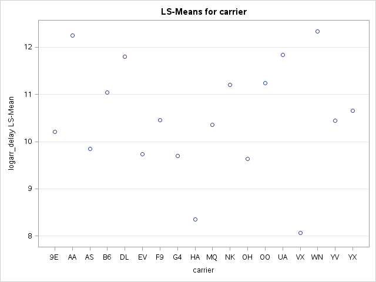

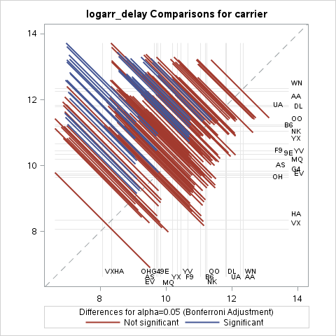